# Cryptocurrency Data Analysis in Python

# Task 1: Identify one or more API's

**1. CryptoCompare API**

The aim of this project is to perform data analysis on cryptocurrency.

For this purpose we decided to use CryptoCompare API which provides data across 200+ exchanges and 5000+ coins.

It provides daily OHLCV (Open High Low Close Volume) data for coins exchange wise or even aggregated data across all exchanges.

https://min-api.cryptocompare.com/  
apikey='XXXXXXXXXXXXXXXXX'

**2. Pytrends library**

To fetch Google Trend data for a given time period regarding a particular search term

**3. Alpha Vantage API**

To fetch daily stock data  
apikey="XXXXXXXXXXXXXXXXXXXXXXXX"

### Firstly, we will load the necessary libraries and install, if required

```python
import requests
import pandas as pd
from datetime import datetime, date
import time
import json
import seaborn as sns
import matplotlib.pyplot as plt
import matplotlib as mpl
import csv
import urllib.request
import os
```

### Install pytrends

```python
!pip install pytrends
```

```python
from pytrends.request import TrendReq
```

# Task 2,3: Data Collection and Storage

**Note: The data has already been fetched and required files have been attached**

### URL's required for API calls

```python
COIN_LIST_URL = 'https://www.cryptocompare.com/api/data/coinlist/'
PRICE_MULTI_FULL_URL = 'https://min-api.cryptocompare.com/data/pricemultifull?fsyms={}&tsyms={}&api_key={}'
DAILY_OHLCV_URL = 'https://min-api.cryptocompare.com/data/histoday?fsym={}&tsym=USD&toTs={}&allData=true&api_key={}'
DAILY_EXCHANGE_URL = 'https://min-api.cryptocompare.com/data/exchange/histoday?tsym=USD&limit=1500&e={}&api_key={}'
BITFINEX_BTC_URL = 'https://min-api.cryptocompare.com/data/histoday?fsym=BTC&tsym=USD&limit=1500&e=Bitfinex&api_key={}'
DAILY_OHLCV_EX_URL = 'https://min-api.cryptocompare.com/data/histoday?fsym={}&tsym=USD&toTs={}&e={}&api_key={}&limit=1000'
```

### Below are the Definitions that are written to fetch data, modify it and also to check the retrieved data

```python
""" This is the main function which queries the CryptoCompare API and fetches the response.
    The data is fetched in json format.
"""
def get_cryptocompare_data(url):
    #We try to make an API call and fetch the data in json format
    try:
        response = requests.get(url).json()
    #In case of request failure we print the error message and None as the response
    except Exception as e:
        print('Error in retrieving coin list'+str(e))
        return None
    return response

"""This function fetches list of all the coins on the CryptoCompare API
"""
def get_coins():
    #We pass the COIN_LIST_URL to get_cryptocompare_data which fetches list of all available coins.
    response = get_cryptocompare_data(COIN_LIST_URL)['Data']
    return response
```

```python
"""This function is used to append parameters to the API URL
"""
def format_url(param):
    #We check if the parameter is a list. IF yes, then we join all the values with ',' as a separator
    if isinstance(param, list):
        return ','.join(param)
    else:
        return param

"""The function is used to get all the price information like price, volume, marketcap, OHLCV etc for a particular coin.
   The URL is: 'https://min-api.cryptocompare.com/data/pricemultifull?fsyms={}&tsyms={}&api_key={}'
   Here, fsyms -- List of coins
         tsyms -- Currency in which we want to convert the price values eg: USD
"""
def get_price_info(coin_list, curr):
    return get_cryptocompare_data(PRICE_MULTI_FULL_URL.format(format_url(coin_list),format_url(curr), format_url(apikey)))
```

```python
"""The function is used to fetch daily historical OHLCV (Open High Low Close Volume) data for a coin.
   The OHLCV values will be aggregated values over all the exchanges present on CryptoCompare API for that coin.
   eg: OHLCV values for BTC will be the aggregated price of BTC over all the exchanges
   'https://min-api.cryptocompare.com/data/histoday?fsym={}&tsym=USD&toTs={}&allData=true&api_key={}'
   Here, fsyms   -- List of coins
         tsyms   -- Currency in which we want to convert the price values eg: USD
         allData -- Retreive all the available data for that coin
         toTs    -- retrieve all the data present prior to the mentioned date.
"""
def get_daily_ohlcv_data(coin):
    #We fetch the current date and convert it into Unix Epoch as required by API
    now = datetime.now()
    date = time.mktime(now.timetuple())
    #It will retrieve all the data present prior to the mentioned date.
    return get_cryptocompare_data(DAILY_OHLCV_URL.format(format_url(coin),format_url(date), format_url(apikey)))
```

```python
"""The function is used to fetch daily historical OHLCV (Open High Low Close Volume) data for a coin on a particular exchange.
   eg: OHLCV values for BTC will be retrieved based on price of BTC over that exchange
   'https://min-api.cryptocompare.com/data/histoday?fsym={}&tsym=USD&toTs={}&e={}&api_key={}&limit=1000'
   Here, fsyms   -- List of coins
         tsyms   -- Currency in which we want to convert the price values eg: USD
         toTs    -- retrieve all the data present prior to the mentioned date.
         limit   -- limit number of records retrieved
         e       -- Specify the exchange
"""
def get_daily_ohlcv_ex_data(exchange, coin='BTC'):
    #We fetch the current date and convert it into Unix Epoch as required by API
    now = datetime.now()
    #now = datetime(2019, 3, 24, 16, 54, 22, 685967)
    date = time.mktime(now.timetuple())
    #It will retrieve all the data present prior to the mentioned date.
    return get_cryptocompare_data(DAILY_OHLCV_EX_URL.format(format_url(coin),format_url(date), format_url(exchange), format_url(apikey)))
```

```python
"""The function is used to fetch daily historical volume of transactions on a exchange.
   'https://min-api.cryptocompare.com/data/exchange/histoday?tsym=USD&limit=1500&e={}&api_key={}'
   Here, tsyms -- Currency in which we want to convert the price values eg: USD
         limit -- Limit the number of data points to be retrieved
         e     -- Specify the exchange for which we want the daily volume data eg: Kraken
"""
def get_daily_exchange_data(exchange):
    return get_cryptocompare_data(DAILY_EXCHANGE_URL.format(format_url(exchange), format_url(apikey)))
```

```python
"""The function is used to convert the Unix Epoch time that is recieved as response from API call to datetime.
   Further, we also set the 'time' column as a dataframe index and sort the date in ascending order.
"""
def convert_time(df):
    #convert the Unix Epoch time to Datetime
    df['time'] = pd.to_datetime(df['time'], unit='s')
    #Set 'time' as dataframe index
    df.set_index('time', inplace=True)
    #Sort data based on index
    df.sort_index(ascending=True, inplace=True)
    return df
```

```python
"""Check if the dataframe contains any duplicate rows or any missing date between the time interval for which data has been fetched
   Input is dict of dataframes and key list to iterate on the dictionary
"""
def check_dataframes(df_dict, key_list):
    dates=[]
    #Iterate over all the dataframes in the dictionary
    for key,i in zip(key_list,range(0,len(key_list))):

        #Fetch first and last date in the dataframe
        dates.append(df_dict[key].index[[0,-1]])
        d1 = dates[i][0].date()
        d2 = dates[i][1].date()

        #Check if there is any duplicate rows present
        isduplicate = df_dict[key][df_dict[key].index.duplicated()].empty

        """If the difference between first and last date is equal to number of rows in dataframe and if there are no duplicate records
           then, it means we have fetched the data correctly
        """
        if (abs((d2 - d1).days)+1 == df_dict[key].shape[0]) and isduplicate:
            print("Collected data for "+key+" does not contain any duplicate values & has data for all dates in the interval "+
            str(d1)+" -- "+str(d2))
```

## Fetch daily OHLCV data for ["BTC","ETH","LTC","XRP","XVG","DOGE"]

```python
#XXXXXX
#Fetch the daily OHLCV data for all the above coins
for coin in coins:
    ohlcv_data = get_daily_ohlcv_data(coin)
    #Store the data fetched in json file
    with open('data\ohlcv_data_'+coin+'.json', 'w') as outfile:
        json.dump(ohlcv_data, outfile)
```

## Fetch daily historical data of volume of transactions done on the particular exchange

```python
#XXXXXXXX
#Iterate over each exchange
for exchange in exchanges:
    #Fetch daily historical data of volume of transactions done on the particular exchange
    exchange_data = get_daily_exchange_data(exchange)
    #Store the json data into a json file
    with open('data\exchange_data_'+exchange+'.json', 'w') as outfile:
        json.dump(exchange_data, outfile)
```

## Fetch daily OHLCV data for BTC on a exchange

```python
#Iterate over each exchange
for exchange in exchanges:
    #Get the daily OHLCV data for BTC on a exchange
    ex_data = get_daily_ohlcv_ex_data(exchange)
    #Store the data in a json file
    with open('data\ohlcv_'+exchange+'_data_BTC.json', 'w') as outfile:
            json.dump(ex_data, outfile)
```

## Fetch Google Trends Data

```python
"""Function to fetch Google Trends data using PyTrends API
   input: list of keyword to be searched and StartDate
   output: Google trends data stored in a dataframe
"""

def fetch_google_trends_data(keyword,startDate):
    pytrend = TrendReq()
    end_date=datetime.today().strftime('%Y-%m-%d')
    tf=startDate+' '+end_date
    pytrend.build_payload(keyword, cat=0, timeframe=tf, geo='', gprop='')
    gt_coin_df = pytrend.interest_over_time()
    gt_coin_df.to_csv("data\\Google Trends\\"+keyword[0]+".csv", encoding='utf-8')
```

```python
#Get Google trends data for bitcoin and ethereum keywords and store it in CSV file
fetch_google_trends_data(['bitcoin'],start_date_btc)
fetch_google_trends_data(['ethereum'],start_date_eth)
```

```python
"""Function for calculating the formula for min/max normalization"""

def min_max_norm(df,colName):
    df[colName] = (df[colName] - df[colName].min())/ (df[colName].max() - df[colName].min())
    return df
```

```python
"""Function to drop the column isPartial from google trends data"""

def drop_col_isPartial(df):
    df=df.drop(['isPartial'], axis=1)
    return df
```

```python
"""Function to convert Daily basis data into monthly data
"""
def convert_daily_to_monthly(df):
    df = df.resample('MS',how={'close':'mean'})
    return df
```

```python
"""
function to plot the goolge trends data and crypto data i.e. close price of the coins
"""
def plot_googletrends_vs_price(df_gt,df_price,coin):
    plt.figure(figsize=(25,8))
    plt.plot(df_price.index,df_price['close'],label= coin+' price')
    plt.plot(df_gt.index,df_gt[coin.lower()],color='red',label=coin+' google trends')
    plt.legend(loc='upper left', prop={'size': 20})
    plt.title('Google trends VS Crypto data',fontsize=18)
    plt.xlabel('Year',fontsize=18)
    plt.ylabel('Min/Max Normalization',fontsize=18)
    #plt.text(10,5,"looooo")
    plt.show()
```

## Fetch Stock Market Data

```python
""" To fetch the price of the below mentioned Stocks over the period of time using Alpha Vantage API
"""
stocks_list=["GOOGL","NVDA","AMD","DJI","NDAQ","INTC"]
for s in stocks_list:
    url="https://www.alphavantage.co/query?function=TIME_SERIES_DAILY&symbol="+s+"&outputsize=full&apikey=XXXXXXXXXX&datatype=csv"
    #print(url)
    response = urllib.request.urlopen(url)
    csv_data = response.read().decode()
    with open("data\\Stock Price\\"+s+"_stocks_data.csv", "a", encoding="utf8") as file:
        f = csv.writer(file)
        lines = csv_data.strip().split("\n")
        for l in lines:
            l = l.split(",")
            f.writerow(l)
        #print(l[0])
    time.sleep(20)
```

# Task 4,5: Data Preparation, Integration and Analysis

** Note: The data is fetched from multiple API's and for multiple cases. The data is collected based on analysis done and hence not divided into individual task. For every analysis, Task 4-5 are performed and listed in that section **

## 1. Find Top 10 coins

```python
#We fetch list of all coins on CryptoCompare API
all_coins = get_coins()
#From the json response we fetch keys i.e coins
coins = sorted(list(all_coins.keys()))
len(coins)
```

```
3810
```

```python
all_coin_data = {}
#Then we loop over 50 coins at a time
for i in range(len(coins)//50+1):
    coin_list = coins[(50*i):(50*i+50)]
    #fetch price, marketcap, OHLCV information for a coin. The price information is converted in USD
    data = get_price_info(coin_list, curr='USD')
    #Update the dictionary with RAW data for each set of 50 coins
    all_coin_data.update(data['RAW'])
```

```python
all_coin_data['BTC']
```

```
{'USD': {'TYPE': '5',
  'MARKET': 'CCCAGG',
  'FROMSYMBOL': 'BTC',
  'TOSYMBOL': 'USD',
  'FLAGS': '2',
  'PRICE': 3927.56,
  'LASTUPDATE': 1553561546,
  'LASTVOLUME': 0.29145218,
  'LASTVOLUMETO': 1139.519733364,
  'LASTTRADEID': '15535615460173670000',
  'VOLUMEDAY': 923.9517362066952,
  'VOLUMEDAYTO': 3636499.2094537024,
  'VOLUME24HOUR': 34587.644191141095,
  'VOLUME24HOURTO': 137931707.75748998,
  'OPENDAY': 3924.55,
  'HIGHDAY': 3935.33,
  'LOWDAY': 3924.11,
  'OPEN24HOUR': 3981.73,
  'HIGH24HOUR': 4015.57,
  'LOW24HOUR': 3880.02,
  'LASTMARKET': 'Bitlish',
  'VOLUMEHOUR': 923.9517362066952,
  'VOLUMEHOURTO': 3636499.2094537024,
  'OPENHOUR': 3924.55,
  'HIGHHOUR': 3935.33,
  'LOWHOUR': 3924.11,
  'CHANGE24HOUR': -54.17000000000007,
  'CHANGEPCT24HOUR': -1.3604639189498051,
  'CHANGEDAY': 3.0099999999997635,
  'CHANGEPCTDAY': 0.07669669134040243,
  'SUPPLY': 17610075,
  'MKTCAP': 69164626167,
  'TOTALVOLUME24H': 410894.2592427219,
  'TOTALVOLUME24HTO': 1615898516.7694767,
  'IMAGEURL': '/media/19633/btc.png'}}
```

```python
#We remove the USD level as it is common across all coins
for i in all_coin_data.keys():
    all_coin_data[i] = all_coin_data[i]['USD']
all_coin_data['BTC']
```

```
{'TYPE': '5',
 'MARKET': 'CCCAGG',
 'FROMSYMBOL': 'BTC',
 'TOSYMBOL': 'USD',
 'FLAGS': '2',
 'PRICE': 3927.56,
 'LASTUPDATE': 1553561546,
 'LASTVOLUME': 0.29145218,
 'LASTVOLUMETO': 1139.519733364,
 'LASTTRADEID': '15535615460173670000',
 'VOLUMEDAY': 923.9517362066952,
 'VOLUMEDAYTO': 3636499.2094537024,
 'VOLUME24HOUR': 34587.644191141095,
 'VOLUME24HOURTO': 137931707.75748998,
 'OPENDAY': 3924.55,
 'HIGHDAY': 3935.33,
 'LOWDAY': 3924.11,
 'OPEN24HOUR': 3981.73,
 'HIGH24HOUR': 4015.57,
 'LOW24HOUR': 3880.02,
 'LASTMARKET': 'Bitlish',
 'VOLUMEHOUR': 923.9517362066952,
 'VOLUMEHOURTO': 3636499.2094537024,
 'OPENHOUR': 3924.55,
 'HIGHHOUR': 3935.33,
 'LOWHOUR': 3924.11,
 'CHANGE24HOUR': -54.17000000000007,
 'CHANGEPCT24HOUR': -1.3604639189498051,
 'CHANGEDAY': 3.0099999999997635,
 'CHANGEPCTDAY': 0.07669669134040243,
 'SUPPLY': 17610075,
 'MKTCAP': 69164626167,
 'TOTALVOLUME24H': 410894.2592427219,
 'TOTALVOLUME24HTO': 1615898516.7694767,
 'IMAGEURL': '/media/19633/btc.png'}
```

```python
#Convert the data into a DataFrame
all_coin_data = pd.DataFrame.from_dict(all_coin_data, orient='index')
all_coin_data.head()
```

|  | TYPE | MARKET | FROMSYMBOL | TOSYMBOL | FLAGS | PRICE | LASTUPDATE | LASTVOLUME | LASTVOLUMETO | LASTTRADEID | ... | LOWHOUR | CHANGE24HOUR | CHANGEPCT24HOUR | CHANGEDAY | CHANGEPCTDAY | SUPPLY | MKTCAP | TOTALVOLUME24H | TOTALVOLUME24HTO | IMAGEURL |
| --- | --- | --- | --- | --- | --- | --- | --- | --- | --- | --- | --- | --- | --- | --- | --- | --- | --- | --- | --- | --- | --- |
| 007 | 5 | CCCAGG | 007 | USD | 4 | 1.073921 | 1553561512 | 0.0 | 0.00000 | 0 | ... | 1.073921 | 0.000000 | 0.000000 | 0.000000 | 0.000000 | 0.000000e+00 | 0.000000e+00 | 0.0 | 0.000000 | /media/350595/007.png |
| 0XBTC | 5 | CCCAGG | 0XBTC | USD | 4 | 0.134239 | 1553561512 | 0.0 | 0.00000 | 0 | ... | 0.134239 | 0.000000 | 0.000000 | -0.001612 | -1.186759 | 2.099998e+07 | 2.819010e+06 | 0.0 | 0.000000 | /media/32655871/0xbtc.jpg |
| 1337 | 5 | CCCAGG | 1337 | USD | 4 | 0.000085 | 1544912152 | 4000.0 | 0.33952 | 200004203 | ... | NaN | 0.000000 | 0.000000 | 0.000000 | 0.000000 | 2.918197e+10 | 2.476965e+06 | 0.0 | 0.000000 | /media/35520987/elite.png |
| 1CR | 5 | CCCAGG | 1CR | USD | 4 | 0.100680 | 1553561512 | 0.0 | 0.00000 | 0 | ... | NaN | 0.000000 | 0.000000 | 0.000000 | 0.000000 | 8.821300e+04 | 8.881285e+03 | 0.0 | 0.000000 | /media/20175/1cr.png |
| 1ST | 5 | CCCAGG | 1ST | USD | 4 | 0.046420 | 1553561512 | 0.0 | 0.00000 | 0 | ... | 0.046420 | -0.000456 | -0.973654 | 0.000000 | 0.000000 | 8.555836e+07 | 3.971636e+06 | 112138.9 | 5205.509269 | /media/351524/1st.png |

5 rows × 35 columns

```python
#Sort the above dataframe based on market cap of each coin
all_coin_data = all_coin_data.sort_values('MKTCAP', ascending=False)
all_coin_data.head(10)
```

|  | TYPE | MARKET | FROMSYMBOL | TOSYMBOL | FLAGS | PRICE | LASTUPDATE | LASTVOLUME | LASTVOLUMETO | LASTTRADEID | ... | LOWHOUR | CHANGE24HOUR | CHANGEPCT24HOUR | CHANGEDAY | CHANGEPCTDAY | SUPPLY | MKTCAP | TOTALVOLUME24H | TOTALVOLUME24HTO | IMAGEURL |
| --- | --- | --- | --- | --- | --- | --- | --- | --- | --- | --- | --- | --- | --- | --- | --- | --- | --- | --- | --- | --- | --- |
| HIVE | 5 | CCCAGG | HIVE | USD | 4 | 0.038883 | 1553561546 | 0.000000 | 0.000000 | 0 | ... | 0.038883 | 0.000000 | 0.000000 | 0.000000 | 0.000000 | 1.000000e+17 | 3.888284e+15 | 0.000000e+00 | 0.000000e+00 | /media/20780800/flat.png |
| XPD | 5 | CCCAGG | XPD | USD | 4 | 1332.888850 | 1548655349 | 1.960000 | 2612.462146 | ca03b855-7d57-410b-a889-6decef117457 | ... | 1332.888850 | 0.000000 | 0.000000 | -0.001150 | -0.000086 | 6.399328e+07 | 8.529592e+10 | 0.000000e+00 | 0.000000e+00 | /media/20162/xpd.png |
| WBTC* | 5 | CCCAGG | WBTC* | USD | 4 | 3927.700000 | 1553561558 | 0.000000 | 0.000000 | 0 | ... | 3927.700000 | 0.000000 | 0.000000 | 0.000000 | 0.000000 | 2.100000e+07 | 8.248170e+10 | 0.000000e+00 | 0.000000e+00 | /media/1383045/wbtc.png |
| BTC | 5 | CCCAGG | BTC | USD | 2 | 3927.560000 | 1553561546 | 0.291452 | 1139.519733 | 15535615460173670000 | ... | 3924.110000 | -54.170000 | -1.360464 | 3.010000 | 0.076697 | 1.761008e+07 | 6.916463e+10 | 4.108943e+05 | 1.615899e+09 | /media/19633/btc.png |
| AMIS | 5 | CCCAGG | AMIS | USD | 4 | 1895.468800 | 1553561512 | 0.000000 | 0.000000 | 0 | ... | 1895.468800 | 0.000000 | 0.000000 | 0.000000 | 0.000000 | 2.000000e+07 | 3.790938e+10 | 0.000000e+00 | 0.000000e+00 | /media/1382862/amis.png |
| CR | 5 | CCCAGG | CR | USD | 1 | 16.108800 | 1553561512 | 0.000000 | 0.000000 | 0 | ... | 8.188640 | -2.684800 | -14.285714 | 0.000000 | 0.000000 | 2.000000e+09 | 3.221760e+10 | 2.518743e+04 | 4.057392e+05 | /media/35520996/cr.png |
| XRP | 5 | CCCAGG | XRP | USD | 4 | 0.302700 | 1553561554 | 50.000000 | 15.070000 | 226955 | ... | 0.302300 | -0.004300 | -1.400651 | 0.000300 | 0.099206 | 9.999185e+10 | 3.026753e+10 | 1.186124e+09 | 3.590830e+08 | /media/34477776/xrp.png |
| BITCNY | 5 | CCCAGG | BITCNY | USD | 4 | 0.151658 | 1553561512 | 0.000000 | 0.000000 | 0 | ... | 0.152407 | 0.002751 | 1.847145 | -0.000333 | -0.219172 | 1.000000e+11 | 1.516579e+10 | 0.000000e+00 | 0.000000e+00 | /media/351490/bitcny.png |
| ETH | 5 | CCCAGG | ETH | USD | 1 | 134.240000 | 1553561512 | 0.135541 | 18.070267 | 45814920 | ... | 133.860000 | -1.900000 | -1.395622 | 0.280000 | 0.209018 | 1.053888e+08 | 1.414739e+10 | 9.815336e+06 | 1.317691e+09 | /media/20646/eth_logo.png |
| CREDIT | 5 | CCCAGG | CREDIT | USD | 4 | 0.216017 | 1553561555 | 0.000000 | 0.000000 | 0 | ... | 0.216017 | 0.000000 | 0.000000 | 0.000000 | 0.000000 | 3.082571e+10 | 6.658891e+09 | 0.000000e+00 | 0.000000e+00 | /media/35521112/credit.png |

10 rows × 35 columns

The reason is that CryptoCompare has data about coins which are not yet listed on ICO. Hence, for those coins it considers the coins price based on pre-ICO value.

Therefore, we elimiate the coins that are not traded in last 24 hours or the last traded volume is 0.

```python
#Filter out the rows whose TOTALVOLUME24H and LASTVOLUME = 0
all_coin_data = all_coin_data[(all_coin_data['TOTALVOLUME24H'] != 0) & (all_coin_data['LASTVOLUME'] != 0)]
all_coin_data.head(10)
```

|  | TYPE | MARKET | FROMSYMBOL | TOSYMBOL | FLAGS | PRICE | LASTUPDATE | LASTVOLUME | LASTVOLUMETO | LASTTRADEID | ... | LOWHOUR | CHANGE24HOUR | CHANGEPCT24HOUR | CHANGEDAY | CHANGEPCTDAY | SUPPLY | MKTCAP | TOTALVOLUME24H | TOTALVOLUME24HTO | IMAGEURL |
| --- | --- | --- | --- | --- | --- | --- | --- | --- | --- | --- | --- | --- | --- | --- | --- | --- | --- | --- | --- | --- | --- |
| BTC | 5 | CCCAGG | BTC | USD | 2 | 3927.56000 | 1553561546 | 0.291452 | 1139.519733 | 15535615460173670000 | ... | 3924.11000 | -54.17000 | -1.360464 | 3.01000 | 0.076697 | 1.761008e+07 | 6.916463e+10 | 4.108943e+05 | 1.615899e+09 | /media/19633/btc.png |
| XRP | 5 | CCCAGG | XRP | USD | 4 | 0.30270 | 1553561554 | 50.000000 | 15.070000 | 226955 | ... | 0.30230 | -0.00430 | -1.400651 | 0.00030 | 0.099206 | 9.999185e+10 | 3.026753e+10 | 1.186124e+09 | 3.590830e+08 | /media/34477776/xrp.png |
| ETH | 5 | CCCAGG | ETH | USD | 1 | 134.24000 | 1553561512 | 0.135541 | 18.070267 | 45814920 | ... | 133.86000 | -1.90000 | -1.395622 | 0.28000 | 0.209018 | 1.053888e+08 | 1.414739e+10 | 9.815336e+06 | 1.317691e+09 | /media/20646/eth_logo.png |
| EOS | 5 | CCCAGG | EOS | USD | 4 | 3.70000 | 1553561540 | 57.144436 | 211.262980 | 345104103 | ... | 3.68000 | 0.03000 | 0.817439 | 0.02000 | 0.543478 | 1.038850e+09 | 3.843745e+09 | 2.465076e+08 | 9.120229e+08 | /media/1383652/eos_1.png |
| LTC | 5 | CCCAGG | LTC | USD | 1 | 59.19000 | 1553561546 | 0.812987 | 47.649196 | 37397731 | ... | 59.10000 | -0.56000 | -0.937238 | 0.03000 | 0.050710 | 6.104669e+07 | 3.613353e+09 | 1.255140e+07 | 7.429839e+08 | /media/35309662/ltc.png |
| BCH | 5 | CCCAGG | BCH | USD | 2 | 158.73000 | 1553561486 | 0.334440 | 53.008689 | 1553561486.056 | ... | 158.73000 | -3.93000 | -2.416083 | -1.06000 | -0.663371 | 1.761006e+07 | 2.795245e+09 | 2.217792e+06 | 3.521572e+08 | /media/1383919/12-bitcoin-cash-square-crop-sma... |
| USDT | 5 | CCCAGG | USDT | USD | 4 | 1.01000 | 1553561554 | 11.991802 | 12.165923 | 84851926 | ... | 1.01000 | 0.00000 | 0.000000 | 0.00000 | 0.000000 | 2.020708e+09 | 2.040915e+09 | 4.115124e+07 | 4.153689e+07 | /media/1383672/usdt.png |
| XLM | 5 | CCCAGG | XLM | USD | 2 | 0.09998 | 1553561546 | 10.000000 | 0.999990 | 70190 | ... | 0.09973 | -0.00362 | -3.494208 | -0.00062 | -0.616302 | 1.922531e+10 | 1.922147e+09 | 6.458886e+08 | 6.465745e+07 | /media/20696/str.png |
| ADA | 5 | CCCAGG | ADA | USD | 4 | 0.06003 | 1553561513 | 50.308000 | 3.018631 | 1553561513.812 | ... | 0.05837 | 0.00029 | 0.485437 | 0.00139 | 2.370396 | 2.592707e+10 | 1.556402e+09 | 1.340547e+09 | 8.045073e+07 | /media/12318177/ada.png |
| TRX | 5 | CCCAGG | TRX | USD | 4 | 0.02286 | 1553561145 | 16013.700000 | 368.573241 | 84851690 | ... | 0.02277 | -0.00055 | -2.349423 | -0.00010 | -0.435540 | 6.671652e+10 | 1.525140e+09 | 6.897571e+09 | 1.576802e+08 | /media/34477805/trx.jpg |

10 rows × 35 columns

Now, we correctly get the list of top 10 coins.

Below is the list of coins that we will be considering for our analysis

## 2. Find if there is any correlation between different cryptocurreny in terms of price

### Data Preparation, Pre-processing and Integration

```python
coins = ["BTC","ETH","LTC","XRP","XVG","DOGE"]
```

```python
ohlcv_dict={}
size=[]
#Load the OHLCV data for each coin
for coin in coins:
    with open('data\ohlcv_data_'+coin+'.json', 'r') as outfile:
        ohlcv_json_data = json.load(outfile)

    #Convert the json data into a DataFrame and append the dataframe to a dictionary
    ohlcv_dict[coin] = pd.DataFrame(ohlcv_json_data['Data'])

    #We take count of rows of each dataframe in a list
    size.append(ohlcv_dict[coin].shape[0])
    print(ohlcv_dict[coin].shape)
```

```
(3171, 7)
(1324, 7)
(1976, 7)
(1522, 7)
(1139, 7)
(1876, 7)
```

```python
for coin in coins:
    print("Info about "+coin)
    display(ohlcv_dict[coin].info())
    display(ohlcv_dict[coin].describe())
```

```
Info about BTC
<class 'pandas.core.frame.DataFrame'>
RangeIndex: 3171 entries, 0 to 3170
Data columns (total 7 columns):
close         3171 non-null float64
high          3171 non-null float64
low           3171 non-null float64
open          3171 non-null float64
time          3171 non-null int64
volumefrom    3171 non-null float64
volumeto      3171 non-null float64
dtypes: float64(6), int64(1)
memory usage: 173.5 KB
```

```
None
```

|  | close | high | low | open | time | volumefrom | volumeto |
| --- | --- | --- | --- | --- | --- | --- | --- |
| count | 3171.000000 | 3171.000000 | 3171.000000 | 3171.000000 | 3.171000e+03 | 3171.000000 | 3.171000e+03 |
| mean | 1604.449676 | 1655.519289 | 1542.946859 | 1603.193921 | 1.416269e+09 | 56777.625380 | 1.516809e+08 |
| std | 2960.223422 | 3071.061944 | 2820.943871 | 2960.074833 | 7.910207e+07 | 54754.508017 | 4.085367e+08 |
| min | 0.049510 | 0.049510 | 0.010000 | 0.049510 | 1.279325e+09 | 0.000000 | 0.000000e+00 |
| 25% | 12.395000 | 12.610000 | 12.135000 | 12.380000 | 1.347797e+09 | 20794.015000 | 5.198783e+05 |
| 50% | 352.190000 | 365.350000 | 343.560000 | 352.010000 | 1.416269e+09 | 42451.230000 | 9.981283e+06 |
| 75% | 985.890000 | 1017.885000 | 935.635000 | 980.695000 | 1.484741e+09 | 74356.470000 | 6.057536e+07 |
| max | 19345.490000 | 19870.620000 | 18750.910000 | 19346.600000 | 1.553213e+09 | 572349.320000 | 6.245732e+09 |

```
Info about ETH
<class 'pandas.core.frame.DataFrame'>
RangeIndex: 1324 entries, 0 to 1323
Data columns (total 7 columns):
close         1324 non-null float64
high          1324 non-null float64
low           1324 non-null float64
open          1324 non-null float64
time          1324 non-null int64
volumefrom    1324 non-null float64
volumeto      1324 non-null float64
dtypes: float64(6), int64(1)
memory usage: 72.5 KB
```

```
None
```

|  | close | high | low | open | time | volumefrom | volumeto |
| --- | --- | --- | --- | --- | --- | --- | --- |
| count | 1324.000000 | 1324.000000 | 1324.000000 | 1324.000000 | 1.324000e+03 | 1.324000e+03 | 1.324000e+03 |
| mean | 204.548629 | 213.080349 | 193.971986 | 204.444460 | 1.496059e+09 | 4.242365e+05 | 1.226256e+08 |
| std | 265.105344 | 277.224535 | 249.829827 | 265.155326 | 3.303506e+07 | 4.613885e+05 | 2.059407e+08 |
| min | 0.420000 | 0.471900 | 0.150000 | 0.420000 | 1.438906e+09 | 0.000000e+00 | 0.000000e+00 |
| 25% | 10.510000 | 10.847500 | 9.955000 | 10.507500 | 1.467482e+09 | 8.170031e+04 | 8.711122e+05 |
| 50% | 95.660000 | 101.865000 | 90.305000 | 95.130000 | 1.496059e+09 | 3.040849e+05 | 4.481139e+07 |
| 75% | 303.655000 | 311.982500 | 292.290000 | 303.647500 | 1.524636e+09 | 5.720803e+05 | 1.712916e+08 |
| max | 1385.020000 | 1422.860000 | 1271.070000 | 1385.020000 | 1.553213e+09 | 3.133632e+06 | 2.034011e+09 |

```
Info about LTC
<class 'pandas.core.frame.DataFrame'>
RangeIndex: 1976 entries, 0 to 1975
Data columns (total 7 columns):
close         1976 non-null float64
high          1976 non-null float64
low           1976 non-null float64
open          1976 non-null float64
time          1976 non-null int64
volumefrom    1976 non-null float64
volumeto      1976 non-null float64
dtypes: float64(6), int64(1)
memory usage: 108.1 KB
```

```
None
```

|  | close | high | low | open | time | volumefrom | volumeto |
| --- | --- | --- | --- | --- | --- | --- | --- |
| count | 1976.000000 | 1976.000000 | 1976.000000 | 1976.000000 | 1.976000e+03 | 1.976000e+03 | 1.976000e+03 |
| mean | 34.018694 | 35.938841 | 32.147743 | 33.989696 | 1.467893e+09 | 7.887080e+05 | 3.049557e+07 |
| std | 54.102849 | 58.074478 | 50.506042 | 54.099746 | 4.929694e+07 | 1.092390e+07 | 1.050050e+08 |
| min | 1.120000 | 1.340000 | 1.120000 | 1.120000 | 1.382573e+09 | 0.000000e+00 | 0.000000e+00 |
| 25% | 3.627500 | 3.700000 | 3.550000 | 3.620000 | 1.425233e+09 | 6.019982e+04 | 2.159762e+05 |
| 50% | 6.520000 | 7.355000 | 5.410000 | 6.050000 | 1.467893e+09 | 2.879476e+05 | 1.148792e+06 |
| 75% | 46.115000 | 48.410000 | 44.135000 | 46.102500 | 1.510553e+09 | 6.311999e+05 | 2.241856e+07 |
| max | 357.510000 | 446.240000 | 324.370000 | 357.510000 | 1.553213e+09 | 4.694749e+08 | 2.375060e+09 |

```
Info about XRP
<class 'pandas.core.frame.DataFrame'>
RangeIndex: 1522 entries, 0 to 1521
Data columns (total 7 columns):
close         1522 non-null float64
high          1522 non-null float64
low           1522 non-null float64
open          1522 non-null float64
time          1522 non-null int64
volumefrom    1522 non-null float64
volumeto      1522 non-null float64
dtypes: float64(6), int64(1)
memory usage: 83.3 KB
```

```
None
```

|  | close | high | low | open | time | volumefrom | volumeto |
| --- | --- | --- | --- | --- | --- | --- | --- |
| count | 1522.000000 | 1522.000000 | 1522.000000 | 1522.000000 | 1.522000e+03 | 1.522000e+03 | 1.522000e+03 |
| mean | 0.223953 | 0.237080 | 0.209344 | 0.223766 | 1.487506e+09 | 4.953925e+07 | 3.162705e+07 |
| std | 0.351444 | 0.380130 | 0.320451 | 0.351476 | 3.797348e+07 | 9.915400e+07 | 1.102623e+08 |
| min | 0.003565 | 0.003565 | 0.003000 | 0.003565 | 1.421798e+09 | 0.000000e+00 | 0.000000e+00 |
| 25% | 0.006701 | 0.007050 | 0.006474 | 0.006708 | 1.454652e+09 | 9.392770e+03 | 5.643000e+01 |
| 50% | 0.013040 | 0.014685 | 0.011420 | 0.013070 | 1.487506e+09 | 7.281868e+06 | 4.714446e+04 |
| 75% | 0.323375 | 0.337125 | 0.313675 | 0.323375 | 1.520359e+09 | 6.121262e+07 | 1.956070e+07 |
| max | 2.780000 | 3.290000 | 2.580000 | 2.780000 | 1.553213e+09 | 1.068869e+09 | 1.565229e+09 |

```
Info about XVG
<class 'pandas.core.frame.DataFrame'>
RangeIndex: 1139 entries, 0 to 1138
Data columns (total 7 columns):
close         1139 non-null float64
high          1139 non-null float64
low           1139 non-null float64
open          1139 non-null float64
time          1139 non-null int64
volumefrom    1139 non-null float64
volumeto      1139 non-null float64
dtypes: float64(6), int64(1)
memory usage: 62.4 KB
```

```
None
```

|  | close | high | low | open | time | volumefrom | volumeto |
| --- | --- | --- | --- | --- | --- | --- | --- |
| count | 1139.000000 | 1139.000000 | 1139.000000 | 1139.000000 | 1.139000e+03 | 1.139000e+03 | 1.139000e+03 |
| mean | 0.015911 | 0.017417 | 0.014556 | 0.015850 | 1.504051e+09 | 4.227950e+08 | 1.701831e+07 |
| std | 0.031512 | 0.036163 | 0.027515 | 0.031374 | 2.842087e+07 | 7.093748e+08 | 6.720538e+07 |
| min | 0.000009 | 0.000016 | 0.000009 | 0.000009 | 1.454890e+09 | 3.601294e+04 | 1.690000e+00 |
| 25% | 0.000030 | 0.000036 | 0.000026 | 0.000030 | 1.479470e+09 | 5.969055e+07 | 1.631445e+03 |
| 50% | 0.004842 | 0.005274 | 0.004375 | 0.004864 | 1.504051e+09 | 2.088171e+08 | 1.276924e+06 |
| 75% | 0.014195 | 0.014615 | 0.013725 | 0.014210 | 1.528632e+09 | 4.318798e+08 | 5.086113e+06 |
| max | 0.252500 | 0.286800 | 0.205600 | 0.253700 | 1.553213e+09 | 8.504830e+09 | 7.879891e+08 |

```
Info about DOGE
<class 'pandas.core.frame.DataFrame'>
RangeIndex: 1876 entries, 0 to 1875
Data columns (total 7 columns):
close         1876 non-null float64
high          1876 non-null float64
low           1876 non-null float64
open          1876 non-null float64
time          1876 non-null int64
volumefrom    1876 non-null float64
volumeto      1876 non-null float64
dtypes: float64(6), int64(1)
memory usage: 102.7 KB
```

```
None
```

|  | close | high | low | open | time | volumefrom | volumeto |
| --- | --- | --- | --- | --- | --- | --- | --- |
| count | 1876.000000 | 1876.000000 | 1876.000000 | 1876.000000 | 1.876000e+03 | 1.876000e+03 | 1.876000e+03 |
| mean | 0.001424 | 0.001569 | 0.001306 | 0.001420 | 1.472213e+09 | 8.972004e+08 | 3.029829e+06 |
| std | 0.002296 | 0.002724 | 0.001863 | 0.002271 | 4.680278e+07 | 1.862411e+09 | 1.131788e+07 |
| min | 0.000056 | 0.000087 | 0.000011 | 0.000049 | 1.391213e+09 | 0.000000e+00 | 0.000000e+00 |
| 25% | 0.000204 | 0.000213 | 0.000192 | 0.000204 | 1.431713e+09 | 4.691776e+07 | 6.694257e+03 |
| 50% | 0.000282 | 0.000301 | 0.000262 | 0.000285 | 1.472213e+09 | 2.524883e+08 | 5.228863e+04 |
| 75% | 0.002090 | 0.002194 | 0.002017 | 0.002089 | 1.512713e+09 | 1.000997e+09 | 2.084298e+06 |
| max | 0.045650 | 0.045650 | 0.014380 | 0.045410 | 1.553213e+09 | 2.466674e+10 | 1.863906e+08 |

Here, we observe that for each coin, we have data for all the columns

Also, we observe that the maximum value of close price is quite large as compared to minimum value

This is because, at start, the value of coin was quite less and gradually as the coins popularity and demand increased prices too increased.

Furthermore, the mean value is not significantly high as maximum close price which means that the maximum value is result of peaks in the coin's price. Also, the coin's initial price has skewed the mean value to a lower value as it takes some time for a coin to get popular and the prices to rise

```python
ohlcv_common_dict={}
#We iterate over the dictionary of OHLCV data containing dataframes for respective coin
for coin in coins:
    df=ohlcv_dict[coin]
    #Convert the Unix Epoch into DateTime, set it as index using convert_time()
    #From the size list we fetch the minimum number of rows and slice each dataframe accordingly
    #Therefore, we now have data for all coins for same period and store this into new dict
    ohlcv_common_dict[coin] = convert_time(df).iloc[-min(size):]
```

```python
#Check for duplicates or missing data
check_dataframes(ohlcv_dict, coins)
```

```
Collected data for BTC does not contain any duplicate values & has data for all dates in the interval 2010-07-17 -- 2019-03-22
Collected data for ETH does not contain any duplicate values & has data for all dates in the interval 2015-08-07 -- 2019-03-22
Collected data for LTC does not contain any duplicate values & has data for all dates in the interval 2013-10-24 -- 2019-03-22
Collected data for XRP does not contain any duplicate values & has data for all dates in the interval 2015-01-21 -- 2019-03-22
Collected data for XVG does not contain any duplicate values & has data for all dates in the interval 2016-02-08 -- 2019-03-22
Collected data for DOGE does not contain any duplicate values & has data for all dates in the interval 2014-02-01 -- 2019-03-22
```

Hence, we successfully fetched daily OHLCV data for each coin.

However, the number of rows retrieved are all different for different coins.

Hence, we fetch the minimum number of rows across all the dataframes and slice the other dataframes accordingly.

Finally, we have a dataframe containing data for same time period and we store these dataframes into a new dict

Now, for further analysis, we want to consider only the close price of each coin

Therefore, we merge the 'close' column of each coin into a dataframe for same time period

```python
merged_df=pd.DataFrame()
#Iterate over each coin
for coin in coins:
    #Fetch 'close' from dataframe of each coin and add it as a column into a new dataframe
    merged_df[coin] = ohlcv_common_dict[coin]['close']
display(merged_df.tail())
print(merged_df.shape)
```

| time | BTC | ETH | LTC | XRP | XVG | DOGE |
| --- | --- | --- | --- | --- | --- | --- |
| 2019-03-18 | 3988.85 | 138.50 | 59.67 | 0.3167 | 0.006781 | 0.002074 |
| 2019-03-19 | 4024.14 | 139.46 | 60.17 | 0.3169 | 0.006881 | 0.002052 |
| 2019-03-20 | 4056.75 | 140.22 | 60.91 | 0.3197 | 0.006896 | 0.002069 |
| 2019-03-21 | 3996.93 | 135.61 | 58.90 | 0.3112 | 0.006875 | 0.002038 |
| 2019-03-22 | 4000.84 | 136.76 | 59.61 | 0.3113 | 0.006921 | 0.002040 |

```
(1139, 6)
```

Gradually, the correlation between prices of various cryptocurriencies seems to rise.

In 2018 onwards, we see that all the cryptocurrencies have become correlated highly. Hence, the price rise in one results to relative rise in other coins as well

### Data Analysis

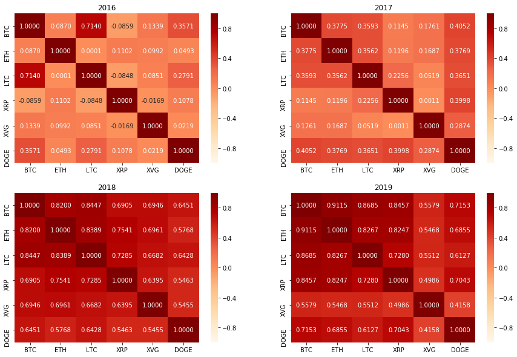

```python
#Years for which we want to find correlation between coins
years=[2016, 2017, 2018, 2019]

fig, ax = plt.subplots(nrows=2, ncols=2, figsize=(15,10))
for year, i in zip(years,range(1,5)):
    #Create a subplot for each year
    plt.subplot(2, 2, i)
    plt.title(year)

    #Filter the merged dataframe containing close prices for each coin yearwise
    dff = merged_df[merged_df.index.year == year]
    #display(dff.pct_change().corr(method='pearson'))

    #Calculate the correlation between % change in prices of coins
    sns.heatmap(dff.pct_change().corr(), vmax=1, vmin=-1, annot=True, fmt = '.4f', cmap="OrRd")
plt.show()
```

### We Plot the price of cryptocurrencies

However, the graph of only price of cryptocurrencies is meaningless as it skews the analysis.

The price of Bitcoin is very high compared to other cyrptocurrencies which does not imply that it is valued more as compared to other cryptocurrencies. Undoubtedly, Bitcoin is very popular but by just looking at the prices it does not imply that it will also yeild higher profits

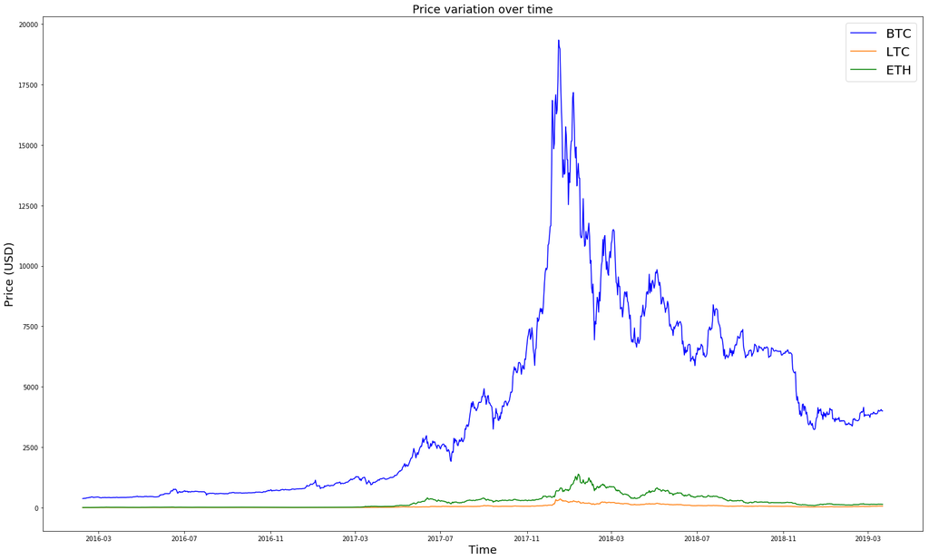

```python
#Change the default color cycle
mpl.rcParams['axes.prop_cycle'] = mpl.cycler(color=["b", "tab:orange","g"])
plt.figure(figsize=(25,15))
#Plot a graph of daily close price of BTC, LTC and ETH
v = plt.plot(merged_df.index, merged_df.loc[:,['BTC','LTC','ETH']])
plt.title('Price variation over time', fontsize=18)
plt.ylabel('Price (USD)', fontsize=18)
plt.xlabel('Time', fontsize=18)
plt.legend(iter(v), ('BTC', 'LTC', 'ETH'), prop={'size': 20})
```

Hence, we consider percentage change instead. This way we get a realistic view.

The below graph gives a overall picture of how the exchange rates have varied for these cryptocurrencies over time.

There have high fluctuations in LTC exchange price which might indicate that we can yeild high profits from it.

Although, we need to do some analysis to find it out. Hence, later we have implemented a strategy to find which cryptocurrency yeilds highest profit.

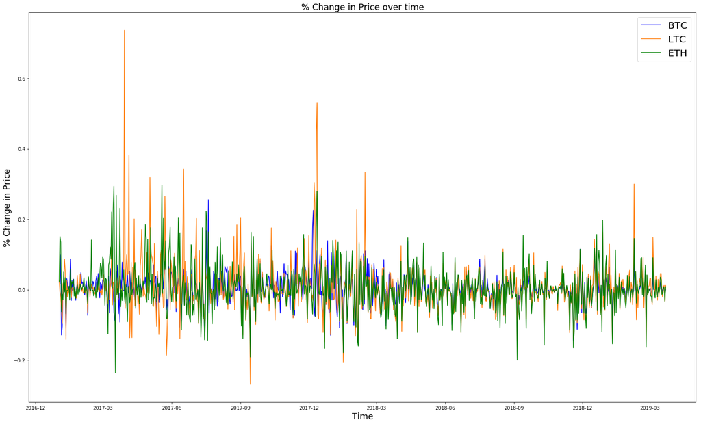

```python
#Change the default color cycle
mpl.rcParams['axes.prop_cycle'] = mpl.cycler(color=["b", "tab:orange","g"])
plt.figure(figsize=(25,15))
#We consider only the data beyond year 2017
yr = merged_df[merged_df.index.year >= 2017]

#Plot % change in daily close price of BTC, LTC and ETH
x = plt.plot(yr.index, yr.loc[:,['BTC','LTC','ETH']].pct_change())
#plt.plot(merged_df.index, merged_df.loc[:,['BTC','LTC','ETH']].pct_change())
plt.title('% Change in Price over time', fontsize=18)
plt.ylabel('% Change in Price', fontsize=18)
plt.xlabel('Time', fontsize=18)
plt.legend(iter(x), ('BTC', 'LTC', 'ETH'), prop={'size': 20})
```

Now, to know the cryptocurrency that yeilds highest profits, we would like to consider relative change in their price rather than absolute price.

Therefore, the below plot rightly indicates relative changes in price over the years.

Also, we can once again prove that there exists high correlation between these cryptocurrencies

```
[Text(0,0.5,'ETH Price (USD)')]
```

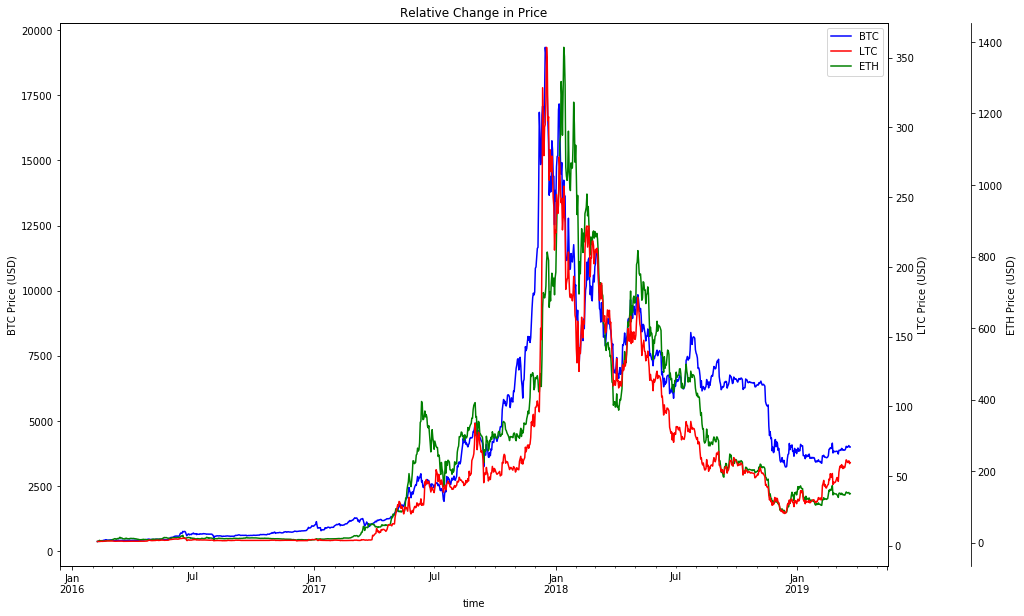

```python
#Plot a relative change in daily close price of BTC, LTC and ETH
fig, axis1 = plt.subplots(figsize=(20, 10))
fig.subplots_adjust(right=0.7)

#We create a second axis and locate it to the right side of the graph
axis2 = axis1.twinx()
axis2_spine = axis2.spines['right']
axis2_spine.set_position(('axes', 1.1))
axis2.set_frame_on(True)
axis2.patch.set_visible(False)

#Plot daily close price of BTC on 1st axis, LTC of dual-y-axis and ETH on the second axis
merged_df['BTC'].plot(ax=axis1, style='b-')
merged_df['LTC'].plot(ax=axis1, style='r-', secondary_y=True)
merged_df['ETH'].plot(ax=axis2, style='g-', title='Relative Change in Price')

# legend
axis2.legend([axis1.get_lines()[0], axis1.right_ax.get_lines()[0],axis2.get_lines()[0]],['BTC', 'LTC', 'ETH'])
axis1.set(ylabel="BTC Price (USD)")
axis1.right_ax.set(ylabel="LTC Price (USD)")
axis2.set(ylabel="ETH Price (USD)")
```

## 3. Find the most famous exchange for trading cryptocurrencies

### Data Preparation, Pre-processing and Integration

```python
#List containing the name of exchanges
exchanges = ["Kraken","Coinbase","Bitfinex","Bitstamp"]
```

```python
#Dict to store the dataframe for each exchange
exchange_dict={}
#Iterate over each exchange
for exchange in exchanges:
    #Load the json file for each exchange
    with open('data\exchange_data_'+exchange+'.json', 'r') as outfile:
        exchange_json_data = json.load(outfile)
    #Extract the Data part and convert it into a dataframe
    df = pd.DataFrame(exchange_json_data['Data'])
    #We convert the Unix Epoch time into Datetime and set it as dataframe index
    exchange_dict[exchange] = convert_time(df)
    #print(exchange_dict[exchange].shape)
```

```python
#Check for duplicates and missing data
check_dataframes(exchange_dict, exchanges)
```

```
Collected data for Kraken does not contain any duplicate values & has data for all dates in the interval 2015-02-13 -- 2019-03-24
Collected data for Coinbase does not contain any duplicate values & has data for all dates in the interval 2015-02-13 -- 2019-03-24
Collected data for Bitfinex does not contain any duplicate values & has data for all dates in the interval 2015-02-13 -- 2019-03-24
Collected data for Bitstamp does not contain any duplicate values & has data for all dates in the interval 2015-02-13 -- 2019-03-24
```

Now, we would like to merge all the 'volume' columns of individual dataframes into a single dataframe

```python
merged_exchange_df=pd.DataFrame()
for exchange in exchanges:
    #Extract the volume column of each exchange and store it as a new column in a new dataframe
    merged_exchange_df[exchange] = exchange_dict[exchange]['volume']
display(merged_exchange_df.tail(3))
```

| time | Kraken | Coinbase | Bitfinex | Bitstamp |
| --- | --- | --- | --- | --- |
| 2019-03-22 | 42086276.26 | 48157350.92 | 73533238.74 | 29742764.67 |
| 2019-03-23 | 37272222.30 | 46737773.26 | 63627241.75 | 18538034.69 |
| 2019-03-24 | 23161585.24 | 29465001.78 | 38722839.44 | 13587856.19 |

## Data Analysis

```python
#Check the basic statistics
display(merged_exchange_df.describe())
display(merged_exchange_df.info())
```

|  | Kraken | Coinbase | Bitfinex | Bitstamp |
| --- | --- | --- | --- | --- |
| count | 1.501000e+03 | 1.501000e+03 | 1.501000e+03 | 1.501000e+03 |
| mean | 9.774403e+07 | 1.190069e+08 | 2.002706e+08 | 7.173781e+07 |
| std | 1.516340e+08 | 2.573283e+08 | 4.303111e+08 | 1.490511e+08 |
| min | 6.584250e+03 | 0.000000e+00 | 0.000000e+00 | 0.000000e+00 |
| 25% | 3.866363e+06 | 2.905719e+06 | 5.865608e+06 | 2.740359e+06 |
| 50% | 2.615712e+07 | 1.581690e+07 | 3.021451e+07 | 1.133427e+07 |
| 75% | 1.371951e+08 | 1.267141e+08 | 2.816899e+08 | 7.377266e+07 |
| max | 1.325569e+09 | 3.352576e+09 | 1.132555e+10 | 1.670025e+09 |

```
<class 'pandas.core.frame.DataFrame'>
DatetimeIndex: 1501 entries, 2015-02-13 to 2019-03-24
Data columns (total 4 columns):
Kraken      1501 non-null float64
Coinbase    1501 non-null float64
Bitfinex    1501 non-null float64
Bitstamp    1501 non-null float64
dtypes: float64(4)
memory usage: 58.6 KB
```

```
None
```

Here, we can see that we have data for all the exchanges and no missing data.

We observe that trading volume on Bitfinex platform appears to be higher

Now, when we graph the trading volume across exchanges we observe a huge spike in Bitfinex exchange trading volume somewhere around mid-2015.

This seems to be an outlier as all the other exchnges have lower trading volume across the entire time period including Bitfinex as even Bitfinex never has such spike anywhere again.

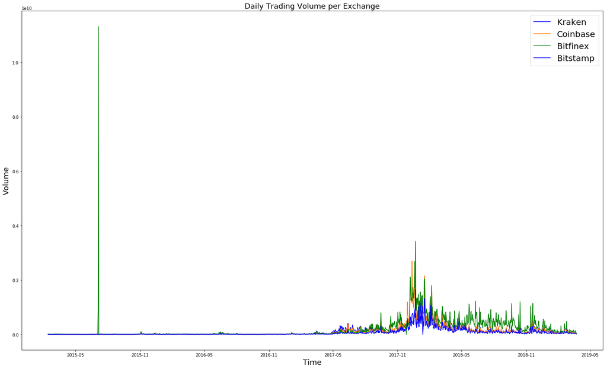

```python
plt.figure(figsize=(25,15))
#Plot trading volume of each exchange over time
y=plt.plot(merged_exchange_df.index, merged_exchange_df.loc[:,exchanges])
plt.title('Daily Trading Volume per Exchange', fontsize=18)
plt.xlabel('Time', fontsize=18)
plt.ylabel('Volume', fontsize=18)
plt.legend(iter(y), exchanges, prop={'size': 20})
```

### Let's check for the spike

```python
#Find the row containing the spike
print(merged_exchange_df[merged_exchange_df.values == merged_exchange_df.values.max()])

#Fetch the date on which the spike occurred
da=merged_exchange_df[merged_exchange_df.values == merged_exchange_df.values.max()].index[0].date()
str(da)
```

```
               Kraken    Coinbase      Bitfinex    Bitstamp
time
2015-07-06  1780521.2  2813809.92  1.132555e+10  5465684.81
```

```
'2015-07-06'
```

In order to check the trading volume on Bitfinex on 2015-07-06, let's fetch the trading volume data for BTC on Bitfinex around that time period

```python
#XXXXXXXXXXX
""" URL: 'https://min-api.cryptocompare.com/data/histoday?fsym=BTC&tsym=USD&limit=1500&e=Bitfinex&api_key={}'
   Here, fsyms -- List of coins
         tsyms -- Currency in which we want to convert the price values eg: USD
         limit -- Limit number of records retrieved
         e     -- Specify exchange name eg: Bitfinex
"""
bitfinex_json_data = get_cryptocompare_data(BITFINEX_BTC_URL.format(format_url(apikey)))

#Store the Bitfinex data regarding daily trading volume for BTC in json file
with open('data\\bitfinex_btc_limit_data.json', 'w') as outfile:
    json.dump(bitfinex_json_data, outfile)
```

```python
#Load the json file
with open('data\\bitfinex_btc_limit_data.json', 'r') as outfile:
    bitfinex_json_data = json.load(outfile)
#Convert the data into a dataframe
bitfinex_data = pd.DataFrame(bitfinex_json_data['Data'])
#Convert Unix Epoch into DateTime and set it as index
bitfinex_data = convert_time(bitfinex_data)
bitfinex_data.tail()
```

| time | close | high | low | open | volumefrom | volumeto |
| --- | --- | --- | --- | --- | --- | --- |
| 2019-03-20 | 4127.16 | 4136.5 | 4072.7 | 4104.58 | 7817.21 | 32067395.84 |
| 2019-03-21 | 4044.80 | 4146.9 | 4004.0 | 4127.16 | 11800.21 | 48162731.29 |
| 2019-03-22 | 4045.20 | 4070.6 | 4034.9 | 4044.80 | 4835.73 | 19582343.14 |
| 2019-03-23 | 4063.20 | 4084.0 | 4028.4 | 4045.20 | 4367.87 | 17714585.85 |
| 2019-03-24 | 4041.40 | 4063.2 | 4011.0 | 4063.20 | 3364.15 | 13586695.95 |

Therefore, now we check for any irregularity in volume data.

```python
#Check if 'volumefrom' > 'volumeto' as the price of bitcoin was never less than 1 during this period
bitfinex_data[bitfinex_data['volumefrom'] > bitfinex_data['volumeto']].dropna()
```

| time | close | high | low | open | volumefrom | volumeto |
| --- | --- | --- | --- | --- | --- | --- |
| 2015-07-06 | 272.0 | 278.69 | 267.33 | 270.17 | 38371.63 | 9641.56 |

We get the same date for which there was a huge spike.

We can clearly see that the volume data is incorrect for this date.

1. VolumeFrom refers to volume in currency that is traded eg: BTC
2. VolumeTo refers to volume in base currency in which trading is done eg: USD

Now, as the price of BTC is higher than 1, it's quite obvious to have volumeto higher than volumefrom.

eg: if we trade 2 BTC then 'volumefrom' is 2 therefore 'volumeto' i.e. volume in USD should be 2*272=544

In our case, we see that 'volumefrom' is higher than 'volumeto' on 2015-07-06 which is impossible given that bitcoin's price in that period is higher than 1

This has caused the spike in trading volume on 2015-07-06 which is incorrect.

We remove the row from dataframe for the date 2015-07-06 and then again plot the data

```python
#Remove the outlier row
cleaned_df = merged_exchange_df[merged_exchange_df != merged_exchange_df.values.max()].dropna()
cleaned_df.shape
```

```
(1500, 4)
```

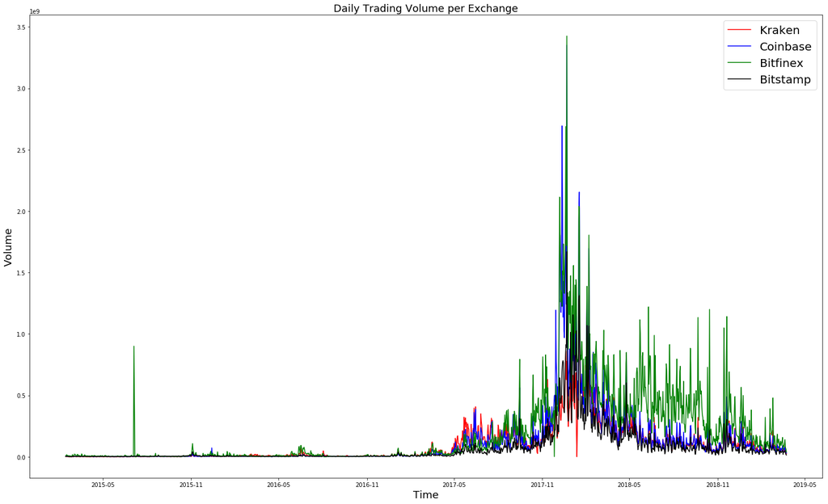

```python
#Change the color cycle
mpl.rcParams['axes.prop_cycle'] = mpl.cycler(color=[ "r","b","g","k"])
plt.figure(figsize=(25,15))

#Plot trading volume of each exchange over time
z=plt.plot(cleaned_df.index, cleaned_df.loc[:,exchanges])
plt.title('Daily Trading Volume per Exchange', fontsize=18)
plt.xlabel('Time', fontsize=18)
plt.ylabel('Volume', fontsize=18)
plt.legend(iter(z), exchanges, prop={'size': 20})
```

Now, we get a realistic view of trading volumes on 4 major platforms: Coinbase, Kraken, Bitfinex and Bitstamp.

We observe that Bitfinex is most popular as it has a higher trading volume.

Out of the two US-based exchanges, Coinbase is more popular than Kraken.

However, we don't know which exchange is more popular for a particular coin. This analysis only indicates the overall popularity of an exchange

## 4. Which Cryptocurrency yeilds higher profits

For this, we consider daily close price data for top coins listed before.

Here, we would be implementing a simple Buy and Hold Strategy.

In this strategy, we buy an asset and keep it for longer periods before finally selling it.

where,  
price0 -- Price on the day of investment  
priceT -- Price on the day we sell

### Data Preparation, Pre-processing and Integration

```python
#Consider only the daily close price from 2019 onwards
merged_df_copy = merged_df[merged_df.index.year == 2019].copy()
merged_df_copy.shape
```

```
(81, 6)
```

```python
merged_df_copy.head(3)
```

| time | BTC | ETH | LTC | XRP | XVG | DOGE |
| --- | --- | --- | --- | --- | --- | --- |
| 2019-01-01 | 3880.15 | 142.66 | 32.12 | 0.3709 | 0.007139 | 0.002406 |
| 2019-01-02 | 3961.01 | 156.57 | 33.40 | 0.3799 | 0.007328 | 0.002416 |
| 2019-01-03 | 3835.86 | 149.44 | 32.03 | 0.3607 | 0.006981 | 0.002340 |

### Data Analysis

```python
#We calculate the returns by dividing close price with inital close price
returns_df = merged_df_copy.apply(lambda x: x/x[0])
returns_df.head(3)
```

| time | BTC | ETH | LTC | XRP | XVG | DOGE |
| --- | --- | --- | --- | --- | --- | --- |
| 2019-01-01 | 1.000000 | 1.000000 | 1.000000 | 1.000000 | 1.000000 | 1.000000 |
| 2019-01-02 | 1.020839 | 1.097505 | 1.039851 | 1.024265 | 1.026474 | 1.004156 |
| 2019-01-03 | 0.988585 | 1.047526 | 0.997198 | 0.972499 | 0.977868 | 0.972569 |

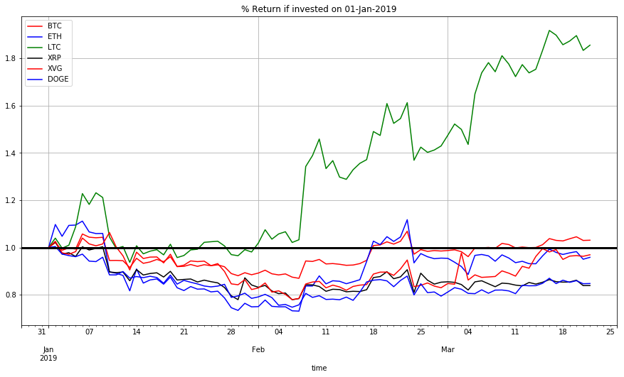

```python
returns_df.plot(grid=True, figsize=(15, 8), title='% Return if invested on 01-Jan-2019').axhline(y = 1, color = "black", lw = 3)
```

After plotting the returns, we see that highest returns are for LTC

### Let's find out overall profit/loss if we sell the cryptos today

```python
#Consider we have a budget of 1000 for each coin
budget=1000

#Find each number of coins we can purchase on 01-01-2019
number_of_coins = merged_df_copy.head(1).apply(lambda x: budget/x)
number_of_coins
```

| time | BTC | ETH | LTC | XRP | XVG | DOGE |
| --- | --- | --- | --- | --- | --- | --- |
| 2019-01-01 | 0.257722 | 7.009673 | 31.13325 | 2696.144513 | 140075.640846 | 415627.597672 |

```python
#Indicates the rise/fall in price as compared to 01-01-2019
returns_df.tail(1)
```

| time | BTC | ETH | LTC | XRP | XVG | DOGE |
| --- | --- | --- | --- | --- | --- | --- |
| 2019-03-22 | 1.031104 | 0.958643 | 1.855853 | 0.83931 | 0.969464 | 0.84788 |

We observe that price of LTC has increase 1.85 times as compared to its price on 01-01-2019

For rest of the coins, the price is nearly the same or has dropped

```python
#Calculate the amount of money that we will make on each crypto if we sell it on today's price
money_made = returns_df.tail(1) * 1000
money_made
```

| time | BTC | ETH | LTC | XRP | XVG | DOGE |
| --- | --- | --- | --- | --- | --- | --- |
| 2019-03-22 | 1031.104468 | 958.642927 | 1855.853051 | 839.309787 | 969.46351 | 847.880299 |

```python
#Subtract the initial 1000 in order to get the profit/loss
returns = money_made-1000
returns
```

| time | BTC | ETH | LTC | XRP | XVG | DOGE |
| --- | --- | --- | --- | --- | --- | --- |
| 2019-03-22 | 31.104468 | -41.357073 | 855.853051 | -160.690213 | -30.53649 | -152.119701 |

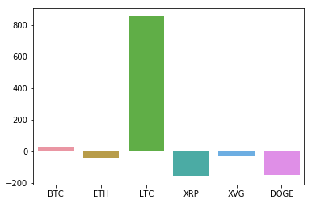

```python
sns.barplot(data=returns)
```

```python
#Compute overall profit or loss
sum(returns.values[0])
```

```
502.2540424609231
```

Therefore, on selling all the cryptos today, we would make a net profit of around $500.

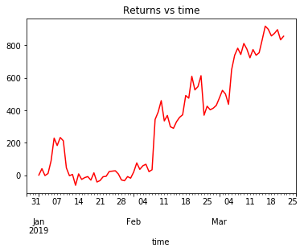

```python
#Compute return for each day
money_made_df = (returns_df['LTC'] * 1000) - 1000
money_made_df.plot(title='Returns vs time')
```

Now, if we compute the return on investment for each day we can see that returns are rising as the price of LTC has been increasing currently as compared to its price at start of the year

## 5. Find if there is any Arbitrage opportunity

Arbitrage is the simultaneous purchase and sale of an asset to profit from an imbalance in the price. It is a trade that profits by exploiting the price differences of identical or similar financial instruments on different markets.

Ref: https://www.investopedia.com/terms/a/arbitrage.asp

For this, we would have to fetch the data daily OHLCV data for BTC across multiple exchanges

### Data Preparation, Pre-processing and Integration

```python
#Dict to store dataframe of each exchangek
ex_dict={}
for exchange in exchanges:
    #Load the json file
    with open('data\ohlcv_'+exchange+'_data_BTC.json', 'r') as outfile:
        ex_json_data = json.load(outfile)
    #Extract Data and convert json into dataframe
    df = pd.DataFrame(ex_json_data['Data'])
    #Convert Unix Epoch into DateTime and set it as index
    ex_dict[exchange] = convert_time(df)
```

```python
print(ex_dict['Kraken'].shape)
#Check for duplicate or missing data
check_dataframes(ex_dict, exchanges)
```

```
(1001, 6)
Collected data for Kraken does not contain any duplicate values & has data for all dates in the interval 2016-06-29 -- 2019-03-26
Collected data for Coinbase does not contain any duplicate values & has data for all dates in the interval 2016-06-29 -- 2019-03-26
Collected data for Bitfinex does not contain any duplicate values & has data for all dates in the interval 2016-06-29 -- 2019-03-26
Collected data for Bitstamp does not contain any duplicate values & has data for all dates in the interval 2016-06-29 -- 2019-03-26
```

```python
#Merge the close price of BTC on each exchange into a single dataframe
merged_ex_df=pd.DataFrame()
for exchange in exchanges:
    #Fetch the close price on a exchange and add it as a column to new dataframe
    merged_ex_df[exchange] = ex_dict[exchange]['close']
display(merged_ex_df.tail())
print(merged_ex_df.shape)
```

| time | Kraken | Coinbase | Bitfinex | Bitstamp |
| --- | --- | --- | --- | --- |
| 2019-03-22 | 3982.1 | 3983.78 | 4045.2 | 3982.07 |
| 2019-03-23 | 3982.5 | 3983.43 | 4063.2 | 3982.52 |
| 2019-03-24 | 3969.3 | 3969.52 | 4041.4 | 3969.99 |
| 2019-03-25 | 3905.9 | 3908.00 | 3970.0 | 3910.51 |
| 2019-03-26 | 3906.4 | 3908.22 | 3975.0 | 3909.17 |

```
(1001, 4)
```

### Data Analysis

In order to check for Arbitrage, we would have to find if there is significant difference in Bitcoin prices across different exchanges at same time interval.

Therefore, we would be performing a two-tailed t-test in order to check if there is significant difference in Bitcoin prices across exchanges

```python
from scipy import stats
```

```python
stats.ttest_ind(merged_ex_df['Bitfinex'], merged_ex_df['Coinbase'])
```

```
Ttest_indResult(statistic=0.025790502085027575, pvalue=0.9794270104933072)
```

We observe that there is higher difference in Bitcoin price between Bitfinex and Coinbase.

Hence, we perform a t-test between those two exchanges under the null hypothesis that the Bitcoin price for both exchanges are the same.

However, the results of the test indicate that there is no statistically significant difference between Bitcoin prices on these two exchanges.

This maybe because the difference in price is quite less compared to the actual Bitcoin price. This results in nearly same mean values which shows that Bitcoin price for both exchanges are the same.

Now, let's consider a different approach.

Here, we find the dates on which if we did an Arbritage, we would have got a profit of more than $200.

To do this, we need to consider following things:

```
1. Buy BTC on one exchange where price is low
2. Transfer it to another exchange
3. Sell it at a higher price
4. Fetch the profit
```

Each of this step requires a transaction fee which restricts the opportunity of Arbitrage

Now, if we assume that the asset will be transferred near real-time The total fee is as follows:

1. Transaction fee on Coinbase - $3
2. Transfer fee to Bitfinex - 1%
3. Sell on Bitfinex - 0.3%
4. Convert profit to USD - 0.6%

```python
#Find the difference in price between Bitfinex and Coinbase
diff = abs(merged_ex_df['Bitfinex'] - merged_ex_df['Coinbase'])
#Compute the transaction fee
tax = (merged_ex_df['Bitfinex'] * 0.02)+3
#Find opportunity of arbitrage where profit is higher than 200
result = merged_ex_df.loc[diff - tax > 200]
result['Profit'] = diff-tax
result
```

| time | Kraken | Coinbase | Bitfinex | Bitstamp | Profit |
| --- | --- | --- | --- | --- | --- |
| 2017-09-04 | 4344.11 | 4498.25 | 4205.0 | 4277.00 | 206.150 |
| 2017-11-26 | 9174.30 | 9401.11 | 8758.8 | 9271.06 | 464.134 |
| 2017-12-06 | 13737.70 | 14090.00 | 13510.0 | 13623.50 | 306.800 |
| 2017-12-07 | 15899.00 | 17390.01 | 16600.0 | 16599.99 | 455.010 |
| 2017-12-09 | 14682.90 | 15309.98 | 14603.0 | 14607.49 | 411.920 |
| 2017-12-12 | 16889.30 | 17730.12 | 16968.0 | 16650.01 | 419.760 |
| 2017-12-22 | 13874.10 | 14210.57 | 13173.0 | 14009.79 | 771.110 |
| 2017-12-23 | 14560.90 | 15065.51 | 14035.0 | 14619.00 | 746.810 |
| 2017-12-24 | 13760.00 | 14221.94 | 13477.0 | 14157.87 | 472.400 |
| 2017-12-25 | 13865.00 | 14171.98 | 13633.0 | 13911.28 | 263.320 |
| 2017-12-30 | 12600.00 | 12839.99 | 12384.0 | 12640.00 | 205.310 |
| 2018-01-16 | 11533.20 | 11570.01 | 11063.0 | 11386.34 | 282.750 |

Hence, we get the above dates on which Arbitrage was possible.

We can extend this analysis further and create predicitve model which will notify an opportunity of Arbitrage

## 6. Google Trends vs Cryptocurrency price

### Data Preparation, Pre-processing and Integration

```python
#Fetch and Create a copy of data for BTC and ETH
bitcoin=ohlcv_dict['BTC'].copy()
ethereum=ohlcv_dict['ETH'].copy()
```

```python
#get minimum date i.e. start date from Bitcoin prices data
min_date_bitcoin=min(bitcoin.index)
start_date_btc=str(min_date_bitcoin.year)+'-'+str(min_date_bitcoin.month)+'-'+str(min_date_bitcoin.day)
print("Start date for Bitcoin data: "+ start_date_btc)
#get minimum date i.e. start date from Ethereum prices data
min_date_ethereum=min(ethereum.index)
start_date_eth=str(min_date_ethereum.year)+'-'+str(min_date_ethereum.month)+'-'+str(min_date_ethereum.day)
print("Start date for Ethereum data: "+ start_date_eth)
```

```
Start date for Bitcoin data: 2010-7-17
Start date for Ethereum data: 2015-8-7
```

```python
#read the data from csv file
gt_bitcoin_df_original=pd.read_csv("data\\Google Trends\\bitcoin.csv",index_col='date')
gt_ethereum_df_original=pd.read_csv("data\\Google Trends\\ethereum.csv",index_col='date')
gt_bitcoin_df_original.index = pd.to_datetime(gt_bitcoin_df_original.index)
gt_ethereum_df_original.index = pd.to_datetime(gt_ethereum_df_original.index)
```

```python
gt_bitcoin_df_original.tail(3)
```

| date | bitcoin | isPartial |
| --- | --- | --- |
| 2019-01-01 | 10 | False |
| 2019-02-01 | 10 | False |
| 2019-03-01 | 9 | True |

```python
#Create a copy of original data
gt_bitcoin_df=gt_bitcoin_df_original.copy()
gt_ethereum_df=gt_ethereum_df_original.copy()
```

```python
#to check if we dont have any duplicate data in our dataset
print(gt_bitcoin_df.index.duplicated().any())
print(gt_ethereum_df.index.duplicated().any())
```

```
False
False
```

```python
"""Filter data as per Bitcoin prices data:
    Here, we are filtering GT bitcoin data to exclude all the values for which year is 2010 or less than 2010
    and for ethereum exclude all the values for which year is 2015 or less than 2015
"""
gt_bitcoin_df=gt_bitcoin_df[gt_bitcoin_df.index.map(lambda x: x.year!=2010)]
gt_ethereum_df=gt_ethereum_df[gt_ethereum_df.index.map(lambda x: x.year>2015)]
```

```python
gt_bitcoin_df.head(3)
```

| date | bitcoin | isPartial |
| --- | --- | --- |
| 2011-01-01 | 0 | False |
| 2011-02-01 | 0 | False |
| 2011-03-01 | 0 | False |

```python
#drop the columns which are not required
gt_bitcoin_df=drop_col_isPartial(gt_bitcoin_df)
gt_ethereum_df=drop_col_isPartial(gt_ethereum_df)
```

```python
gt_bitcoin_df.info()
```

```
<class 'pandas.core.frame.DataFrame'>
DatetimeIndex: 99 entries, 2011-01-01 to 2019-03-01
Data columns (total 1 columns):
bitcoin    99 non-null int64
dtypes: int64(1)
memory usage: 1.5 KB
```

```python
gt_ethereum_df.info()
```

```
<class 'pandas.core.frame.DataFrame'>
DatetimeIndex: 168 entries, 2016-01-03 to 2019-03-17
Data columns (total 1 columns):
ethereum    168 non-null int64
dtypes: int64(1)
memory usage: 2.6 KB
```

```python
#Perform normalization
gt_bitcoin_df=min_max_norm(gt_bitcoin_df,'bitcoin')
gt_ethereum_df=min_max_norm(gt_ethereum_df,'ethereum')
```

Bitcoin Normalization

```python
#filter Bitcoin prices dataset to not containg the year
bitcoin=bitcoin[bitcoin.index.map(lambda x: x.year!=2010)]
```

```python
# convert Bitcoin close price data into monthly data as the Google trends data available through API is in monthly format
bitcoin=convert_daily_to_monthly(bitcoin)
```

```python
#to compare the Bitcoin price and google trends data
bitcoin=min_max_norm(bitcoin,'close')
print(bitcoin.head(3))
#we can see that Bitcoin price dataset has same dimension as bitcoin google trends data
print(bitcoin.shape)
```

```
               close
time
2011-01-01  0.000000
2011-02-01  0.000037
2011-03-01  0.000032
(99, 1)
```

Ethereum Normalization

```python
#get start data from the ethereum google trends data
gt_min_date_ETH=min(gt_ethereum_df.index)
#convert the date into required format
gt_start_date_ETH=str(gt_min_date_ETH.year)+'-'+str(gt_min_date_ETH.month)+'-'+str(gt_min_date_ETH.day)
print(gt_start_date_ETH)
gt_start_date_ETH=pd.to_datetime(gt_start_date_ETH)
```

```
2016-1-3
```

```python
#filter the ethereum price data as per the date fetched from the google trends data so that the dataframes are in sync
ethereum=ethereum[ethereum.index.map(lambda x: x >= gt_start_date_ETH)]
```

```python
#convert the ethereum price daily data into weekly data as the google trends data is in weekly format
ethereum = ethereum.resample('W').agg({'close': 'mean'},
                               loffset = pd.offsets.timedelta(days=+6))
```

```python
#apply min/max normalization to the ethereum price dataset
ethereum=min_max_norm(ethereum,'close')
print(ethereum.head(3))
```

```
               close
time
2016-01-03  0.000000
2016-01-10  0.000004
2016-01-17  0.000183
```

```python
"""
the end date are not in sync for both ethereum google trends data and ethereum price data and hence,
whichever the date is minimum for the end date is taken and accordingly
the data is filtered to get the same end date for both the datasets
"""
eth_price_maxDate=ethereum.index.max()
eth_gt_maxDate=gt_ethereum_df.index.max()
if eth_price_maxDate >= eth_gt_maxDate:
    ethereum=ethereum[ethereum.index.map(lambda x: x <= eth_gt_maxDate)]
else:
    gt_ethereum_df=gt_ethereum_df[gt_ethereum_df.index.map(lambda x: x <= eth_price_maxDate)]
```

```python
#now we can see that Ethereum google trends data and ethereum price data has same dimensions
print(gt_ethereum_df.shape)
print(ethereum.shape)
```

```
(168, 1)
(168, 1)
```

### Data Analysis

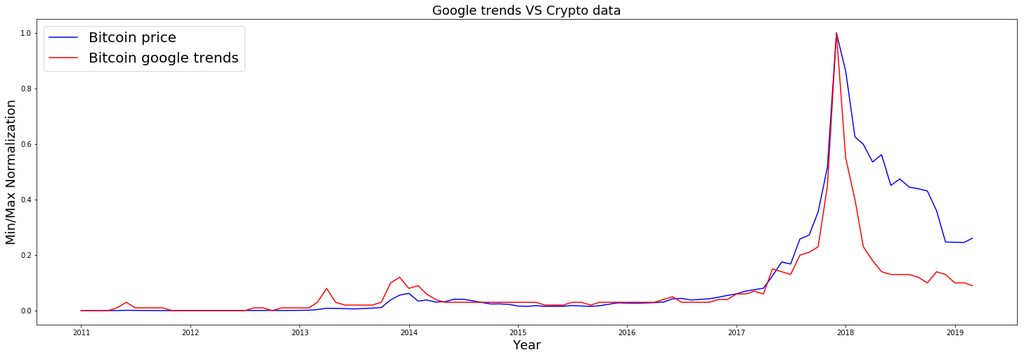

```python
mpl.rcParams['axes.prop_cycle'] = mpl.cycler(color=["b", "r"])
plot_googletrends_vs_price(gt_bitcoin_df,bitcoin,'Bitcoin')
```

```python
""""merge the two dataset i.e. google trends bitcoin data and bitcoin price data into one dataframe to find the corelation"""
merged_gt_price_btc=pd.merge(gt_bitcoin_df, bitcoin, on=bitcoin.index, how='inner')
print("Corelation between bitcoin google trends data and Bitcoin price: ",merged_gt_price_btc.corr().iloc[1,0])
```

```
Corelation between bitcoin google trends data and Bitcoin price:  0.8638846519550691
```

From the above plot and corelation between Google trends data and Bitcoin price we can say that both are corelated to each other. In the initial year like 2013,2014 we can say that increase in google searches was followed by the rise in Bitcoin prices.This type of analysis can be used in a predictive mode; to predict the rise/fall in Bitcoin price as both the terms are highly corelated to each other. We cannot say that Bitcoin google searches are the causation of rise/fall in Bitcoin price but can be used as a factor which indicates the rise/fall of Bticoin price and can be used to build a predictive model to predict the Bitcoin price.

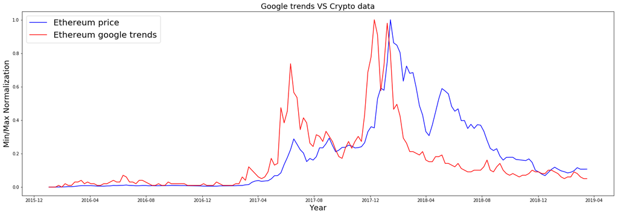

```python
plot_googletrends_vs_price(gt_ethereum_df,ethereum,'Ethereum')
```

```python
""""merge the two dataset i.e. google trends ethereum data and ethereum price data into one dataframe to find the corelation"""
merged_gt_price_eth=pd.merge(gt_ethereum_df,ethereum ,on=gt_ethereum_df.index, how='outer')
```

```python
print("Corelation between Ethereum google trends data and Ethereum price: ",merged_gt_price_eth.corr().iloc[1,0])
```

```
Corelation between Ethereum google trends data and Ethereum price:  0.6387687276860278
```

## 7. Stock Market price vs Bitcoin Price

### Data Preparation, Pre-processing and Integration

```python
""" to read the data from CSV file
"""
GOOGLE_stocks=pd.read_csv("data\\Stock Price\\GOOGL_stocks_data.csv")
NVIDIA_stocks=pd.read_csv("data\\Stock Price\\NVDA_stocks_data.csv")
AMD_stocks=pd.read_csv("data\\Stock Price\\AMD_stocks_data.csv")
DJI_stcoks=pd.read_csv("data\\Stock Price\\DJI_stocks_data.csv")
NDAQ_stcoks=pd.read_csv("data\\Stock Price\\NDAQ_stocks_data.csv")
INTC_stcoks=pd.read_csv("data\\Stock Price\\INTC_stocks_data.csv")
```

```python
""" filter the data to get data from the year 2011
"""
GOOGLE_stocks=GOOGLE_stocks[GOOGLE_stocks['timestamp'].map(lambda x: x >= '2011-01-01')]
NVIDIA_stocks=NVIDIA_stocks[NVIDIA_stocks['timestamp'].map(lambda x: x >= '2011-01-01')]
AMD_stocks=AMD_stocks[AMD_stocks['timestamp'].map(lambda x: x >= '2011-01-01')]
DJI_stcoks=DJI_stcoks[DJI_stcoks['timestamp'].map(lambda x: x >= '2011-01-01')]
NDAQ_stcoks=NDAQ_stcoks[NDAQ_stcoks['timestamp'].map(lambda x: x >= '2011-01-01')]
INTC_stcoks=INTC_stcoks[INTC_stcoks['timestamp'].map(lambda x: x >= '2011-01-01')]
```

```python
""" check if the dimensions of different Stock data are all same
"""
print(GOOGLE_stocks.shape)
print(NVIDIA_stocks.shape)
print(AMD_stocks.shape)
print(DJI_stcoks.shape)
print(NDAQ_stcoks.shape)
print(INTC_stcoks.shape)
```

```
(2068, 6)
(2068, 6)
(2068, 6)
(2068, 6)
(2068, 6)
(2068, 6)
```

```python
""" giving meaningful column names where required
"""
GOOGLE_stocks.rename(columns={'close':'GOOGLE'}, inplace=True)
NVIDIA_stocks.rename(columns={'close':'NVIDIA'}, inplace=True)
AMD_stocks.rename(columns={'close':'AMD'}, inplace=True)
DJI_stcoks.rename(columns={'close':'DOWJONES'}, inplace=True)
NDAQ_stcoks.rename(columns={'close':'NASDAQ'}, inplace=True)
INTC_stcoks.rename(columns={'close':'INTEL'}, inplace=True)
INTC_stcoks.rename(columns={'timestamp':'time'}, inplace=True)
```

```python
""" concatenate all stock prices data into one
"""
stocks_data=pd.concat([GOOGLE_stocks, NVIDIA_stocks,AMD_stocks,DJI_stcoks,NDAQ_stcoks,INTC_stcoks], axis=1)
```

```python
#check if the dimension is still the same after concatenation
print(stocks_data.shape)
stocks_data.columns
```

```
(2068, 36)
```

```
Index(['timestamp', 'open', 'high', 'low', 'GOOGLE', 'volume\r', 'timestamp',
       'open', 'high', 'low', 'NVIDIA', 'volume\r', 'timestamp', 'open',
       'high', 'low', 'AMD', 'volume\r', 'timestamp', 'open', 'high', 'low',
       'DOWJONES', 'volume\r', 'timestamp', 'open', 'high', 'low', 'NASDAQ',
       'volume\r', 'time', 'open', 'high', 'low', 'INTEL', 'volume\r'],
      dtype='object')
```

```python
#drop irrelevant fields from the Stock Prices dataframe
stocks_data=stocks_data.drop(['open','high','low','volume\r','timestamp'], axis=1)
```

```python
stocks_data.columns
```

```
Index(['GOOGLE', 'NVIDIA', 'AMD', 'DOWJONES', 'NASDAQ', 'time', 'INTEL'], dtype='object')
```

```python
stocks_data.head()
```

|  | GOOGLE | NVIDIA | AMD | DOWJONES | NASDAQ | time | INTEL |
| --- | --- | --- | --- | --- | --- | --- | --- |
| 0 | 1207.65 | 177.50 | 26.37 | 25502.3203 | 83.89 | 2019-03-22 | 53.26 |
| 1 | 1236.13 | 183.94 | 27.89 | 25962.5098 | 84.35 | 2019-03-21 | 54.64 |
| 2 | 1226.43 | 174.40 | 25.70 | 25745.6699 | 83.36 | 2019-03-20 | 53.82 |
| 3 | 1202.46 | 175.71 | 26.00 | 25887.3809 | 84.14 | 2019-03-19 | 54.17 |
| 4 | 1188.55 | 168.95 | 23.25 | 25914.0996 | 84.24 | 2019-03-18 | 54.10 |

```python
#stocks_data.info()
stocks_data['time']=pd.to_datetime(stocks_data['time'])
print(stocks_data.info())
```

```
<class 'pandas.core.frame.DataFrame'>
Int64Index: 2068 entries, 0 to 2067
Data columns (total 7 columns):
GOOGLE      2068 non-null float64
NVIDIA      2068 non-null float64
AMD         2068 non-null float64
DOWJONES    2068 non-null float64
NASDAQ      2068 non-null float64
time        2068 non-null datetime64[ns]
INTEL       2068 non-null float64
dtypes: datetime64[ns](1), float64(6)
memory usage: 129.2 KB
None
```

```python
#copy the original data and perform time conversion
bitcoin_stocks=ohlcv_dict['BTC'].copy()
```

```python
#giving meaningful column names where required
bitcoin_stocks.rename(columns={'close':'BTC_Price'}, inplace=True)
```

```python
bitcoin_stocks.info()
```

```
<class 'pandas.core.frame.DataFrame'>
DatetimeIndex: 3171 entries, 2010-07-17 to 2019-03-22
Data columns (total 6 columns):
BTC_Price     3171 non-null float64
high          3171 non-null float64
low           3171 non-null float64
open          3171 non-null float64
volumefrom    3171 non-null float64
volumeto      3171 non-null float64
dtypes: float64(6)
memory usage: 173.4 KB
```

```python
#combine Stock prices data and Bitcoin price data intp one dataframe based on time column
combined_stocks_btc = pd.merge(left=bitcoin_stocks,right=stocks_data, left_on='time', right_on='time')
```

```python
combined_stocks_btc.head(3)
```

|  | time | BTC_Price | high | low | open | volumefrom | volumeto | GOOGLE | NVIDIA | AMD | DOWJONES | NASDAQ | INTEL |
| --- | --- | --- | --- | --- | --- | --- | --- | --- | --- | --- | --- | --- | --- |
| 0 | 2011-01-03 | 0.2950 | 0.2999 | 0.290 | 0.3000 | 1425.19 | 420.85 | 604.35 | 15.82 | 8.47 | 11670.7500 | 24.11 | 20.85 |
| 1 | 2011-01-04 | 0.2989 | 0.2999 | 0.289 | 0.2950 | 1879.00 | 548.33 | 602.12 | 15.77 | 8.77 | 11691.1797 | 23.92 | 21.15 |
| 2 | 2011-01-05 | 0.2990 | 0.2990 | 0.290 | 0.2989 | 357.16 | 106.19 | 609.07 | 16.98 | 8.91 | 11722.8896 | 23.65 | 20.94 |

```python
#drop irrelevant column
combined_stocks_btc=combined_stocks_btc.drop(['open','high','low','volumefrom','volumeto'], axis=1)
```

```python
#check for NaN values
combined_stocks_btc.isnull().any().any()
```

```
False
```

```python
combined_stocks_btc.tail(3)
```

|  | time | BTC_Price | GOOGLE | NVIDIA | AMD | DOWJONES | NASDAQ | INTEL |
| --- | --- | --- | --- | --- | --- | --- | --- | --- |
| 2065 | 2019-03-20 | 4056.75 | 1226.43 | 174.40 | 25.70 | 25745.6699 | 83.36 | 53.82 |
| 2066 | 2019-03-21 | 3996.93 | 1236.13 | 183.94 | 27.89 | 25962.5098 | 84.35 | 54.64 |
| 2067 | 2019-03-22 | 4000.84 | 1207.65 | 177.50 | 26.37 | 25502.3203 | 83.89 | 53.26 |

```python
#normalize the data using Min/Max normalization formula
min_max_norm(combined_stocks_btc,'GOOGLE')
min_max_norm(combined_stocks_btc,'NVIDIA')
min_max_norm(combined_stocks_btc,'AMD')
min_max_norm(combined_stocks_btc,'DOWJONES')
min_max_norm(combined_stocks_btc,'NASDAQ')
min_max_norm(combined_stocks_btc,'INTEL')
min_max_norm(combined_stocks_btc,'BTC_Price')
```

|  | time | BTC_Price | GOOGLE | NVIDIA | AMD | DOWJONES | NASDAQ | INTEL |
| --- | --- | --- | --- | --- | --- | --- | --- | --- |
| 0 | 2011-01-03 | 0.000000e+00 | 0.159717 | 0.015972 | 0.220257 | 0.062786 | 0.048598 | 0.043811 |
| 1 | 2011-01-04 | 2.055658e-07 | 0.156966 | 0.015793 | 0.229904 | 0.064050 | 0.046110 | 0.051729 |
| 2 | 2011-01-05 | 2.108367e-07 | 0.165540 | 0.020145 | 0.234405 | 0.066010 | 0.042573 | 0.046186 |
| 3 | 2011-01-06 | 1.581276e-07 | 0.171005 | 0.028599 | 0.227331 | 0.064429 | 0.041263 | 0.041700 |
| 4 | 2011-01-07 | 1.317730e-06 | 0.174632 | 0.030542 | 0.231833 | 0.063034 | 0.039036 | 0.038797 |
| 5 | 2011-01-10 | 1.665610e-06 | 0.171881 | 0.033279 | 0.243408 | 0.060727 | 0.040084 | 0.039588 |
| 6 | 2011-01-11 | 1.665610e-06 | 0.174101 | 0.032125 | 0.216720 | 0.062856 | 0.044145 | 0.049089 |
| 7 | 2011-01-12 | 1.254479e-06 | 0.175162 | 0.043070 | 0.217685 | 0.068023 | 0.046601 | 0.055753 |
| 8 | 2011-01-13 | 1.191228e-06 | 0.174940 | 0.043205 | 0.213505 | 0.066567 | 0.048598 | 0.055424 |
| 9 | 2011-01-14 | 5.534465e-06 | 0.184180 | 0.043924 | 0.211576 | 0.069998 | 0.052004 | 0.049881 |
| 10 | 2011-01-18 | 9.487654e-07 | 0.203239 | 0.041927 | 0.208441 | 0.073123 | 0.052430 | 0.049947 |
| 11 | 2011-01-19 | 9.487654e-07 | 0.193519 | 0.039679 | 0.202894 | 0.072342 | 0.044276 | 0.048034 |
| 12 | 2011-01-20 | 5.007373e-06 | 0.187375 | 0.039747 | 0.205788 | 0.072188 | 0.047288 | 0.046450 |
| 13 | 2011-01-21 | 6.583377e-06 | 0.168945 | 0.038992 | 0.190354 | 0.075220 | 0.051087 | 0.043019 |
| 14 | 2011-01-24 | 6.583377e-06 | 0.168020 | 0.048025 | 0.194855 | 0.081940 | 0.054526 | 0.054104 |
| 15 | 2011-01-25 | 6.061556e-06 | 0.178912 | 0.045291 | 0.188424 | 0.081734 | 0.051087 | 0.062286 |
| 16 | 2011-01-26 | 6.430521e-06 | 0.174706 | 0.047342 | 0.188778 | 0.082244 | 0.053838 | 0.067564 |
| 17 | 2011-01-27 | 6.651899e-06 | 0.175064 | 0.047093 | 0.197106 | 0.082515 | 0.063008 | 0.067564 |
| 18 | 2011-01-28 | 7.959087e-06 | 0.155572 | 0.044536 | 0.188746 | 0.072243 | 0.053707 | 0.059910 |
| 19 | 2011-01-31 | 1.185957e-05 | 0.154795 | 0.045111 | 0.199678 | 0.076462 | 0.053445 | 0.059910 |
| 20 | 2011-02-01 | 2.134722e-05 | 0.167970 | 0.047090 | 0.212219 | 0.085627 | 0.064580 | 0.060438 |
| 21 | 2011-02-02 | 2.219057e-05 | 0.169154 | 0.051083 | 0.214469 | 0.085739 | 0.080037 | 0.062549 |
| 22 | 2011-02-03 | 2.082013e-05 | 0.166872 | 0.049338 | 0.215756 | 0.086994 | 0.075190 | 0.062813 |
| 23 | 2011-02-04 | 2.719794e-05 | 0.167896 | 0.051407 | 0.218006 | 0.088842 | 0.080692 | 0.065717 |
| 24 | 2011-02-07 | 3.136197e-05 | 0.171986 | 0.047561 | 0.215756 | 0.093138 | 0.083573 | 0.065980 |
| 25 | 2011-02-08 | 3.283782e-05 | 0.177025 | 0.044938 | 0.212862 | 0.097560 | 0.071260 | 0.064529 |
| 26 | 2011-02-09 | 4.190380e-05 | 0.174706 | 0.042845 | 0.212540 | 0.097977 | 0.094053 | 0.059910 |
| 27 | 2011-02-10 | 3.612161e-05 | 0.174632 | 0.041154 | 0.212219 | 0.097322 | 0.097197 | 0.068884 |
| 28 | 2011-02-11 | 4.084962e-05 | 0.184575 | 0.043492 | 0.214148 | 0.100040 | 0.101127 | 0.067828 |
| 29 | 2011-02-14 | 4.084962e-05 | 0.189077 | 0.042197 | 0.225402 | 0.099727 | 0.121037 | 0.062813 |
| ... | ... | ... | ... | ... | ... | ... | ... | ... |
| 2038 | 2019-02-08 | 1.929017e-01 | 0.774099 | 0.492086 | 0.689068 | 0.893523 | 0.873199 | 0.782528 |
| 2039 | 2019-02-11 | 1.903352e-01 | 0.773778 | 0.485898 | 0.686174 | 0.890232 | 0.868483 | 0.780681 |
| 2040 | 2019-02-12 | 1.906552e-01 | 0.805186 | 0.502878 | 0.681672 | 0.913274 | 0.879879 | 0.813407 |
| 2041 | 2019-02-13 | 1.900469e-01 | 0.806481 | 0.509029 | 0.682637 | 0.920540 | 0.885381 | 0.825548 |
| 2042 | 2019-02-14 | 1.891430e-01 | 0.807185 | 0.514965 | 0.691640 | 0.914117 | 0.874509 | 0.834521 |
| 2043 | 2019-02-15 | 1.893944e-01 | 0.795379 | 0.525074 | 0.709325 | 0.941561 | 0.882368 | 0.856954 |
| 2044 | 2019-02-19 | 2.068279e-01 | 0.803866 | 0.522556 | 0.718006 | 0.942060 | 0.883154 | 0.850092 |
| 2045 | 2019-02-20 | 2.094534e-01 | 0.796563 | 0.529427 | 0.718006 | 0.945963 | 0.886560 | 0.849828 |
| 2046 | 2019-02-21 | 2.075026e-01 | 0.776356 | 0.519426 | 0.717042 | 0.939544 | 0.886429 | 0.850356 |
| 2047 | 2019-02-22 | 2.099531e-01 | 0.791592 | 0.531729 | 0.731190 | 0.950747 | 0.899135 | 0.878860 |
| 2048 | 2019-02-25 | 2.026782e-01 | 0.792542 | 0.529930 | 0.742444 | 0.954465 | 0.913545 | 0.894959 |
| 2049 | 2019-02-26 | 2.012218e-01 | 0.798315 | 0.524210 | 0.726367 | 0.952365 | 0.926120 | 0.898390 |
| 2050 | 2019-02-27 | 2.018986e-01 | 0.799400 | 0.518131 | 0.702894 | 0.947862 | 0.922190 | 0.898654 |
| 2051 | 2019-02-28 | 2.015112e-01 | 0.803916 | 0.513994 | 0.704502 | 0.943586 | 0.932277 | 0.891264 |
| 2052 | 2019-03-01 | 2.019386e-01 | 0.831018 | 0.521872 | 0.709325 | 0.950407 | 0.937778 | 0.900238 |
| 2053 | 2019-03-04 | 1.966572e-01 | 0.837063 | 0.523059 | 0.699357 | 0.937628 | 0.913676 | 0.917129 |
| 2054 | 2019-03-05 | 2.041893e-01 | 0.856517 | 0.522124 | 0.703537 | 0.936823 | 0.895206 | 0.910267 |
| 2055 | 2019-03-06 | 2.042315e-01 | 0.851274 | 0.506044 | 0.668489 | 0.928589 | 0.881189 | 0.891000 |
| 2056 | 2019-03-07 | 2.046337e-01 | 0.833893 | 0.496007 | 0.657878 | 0.916209 | 0.858921 | 0.881763 |
| 2057 | 2019-03-08 | 2.038646e-01 | 0.832807 | 0.500971 | 0.655627 | 0.914787 | 0.825779 | 0.878596 |
| 2058 | 2019-03-11 | 2.042267e-01 | 0.868940 | 0.538744 | 0.686174 | 0.927193 | 0.833377 | 0.901557 |
| 2059 | 2019-03-12 | 2.049478e-01 | 0.891133 | 0.543708 | 0.703215 | 0.921244 | 0.830757 | 0.907363 |
| 2060 | 2019-03-13 | 2.044139e-01 | 0.893366 | 0.565652 | 0.699678 | 0.930409 | 0.846869 | 0.928477 |
| 2061 | 2019-03-14 | 2.045720e-01 | 0.885310 | 0.554644 | 0.681672 | 0.930845 | 0.832984 | 0.903932 |
| 2062 | 2019-03-15 | 2.069776e-01 | 0.882559 | 0.569933 | 0.696785 | 0.939435 | 0.827220 | 0.927421 |
| 2063 | 2019-03-18 | 2.102335e-01 | 0.880400 | 0.566839 | 0.695498 | 0.943468 | 0.836259 | 0.921351 |
| 2064 | 2019-03-19 | 2.120936e-01 | 0.897560 | 0.591158 | 0.783923 | 0.941816 | 0.834949 | 0.923199 |
| 2065 | 2019-03-20 | 2.138124e-01 | 0.927130 | 0.586445 | 0.774277 | 0.933054 | 0.824731 | 0.913961 |
| 2066 | 2019-03-21 | 2.106594e-01 | 0.939096 | 0.620764 | 0.844695 | 0.946462 | 0.837700 | 0.935603 |
| 2067 | 2019-03-22 | 2.108655e-01 | 0.903962 | 0.597597 | 0.795820 | 0.918008 | 0.831674 | 0.899182 |

2068 rows × 8 columns

### Data Analysis

```
Text(0.5,1,'Stock Prices VS Bitcoin Price')
```

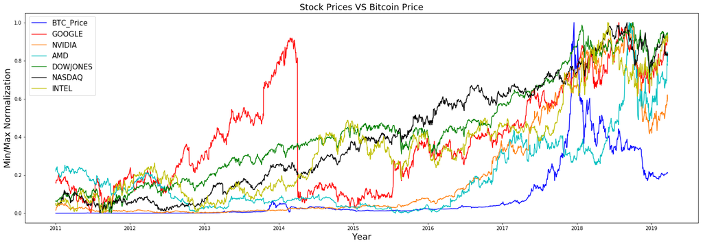

```python
""" Plot Stock market prices VS Bitcoin prices
"""
mpl.rcParams['axes.prop_cycle'] = mpl.cycler(color=["b", "r", 'tab:orange', 'c', 'g', 'k','y'])
plt.figure(figsize=(25,8))
plt.plot(combined_stocks_btc['time'],combined_stocks_btc['BTC_Price'])
plt.plot(combined_stocks_btc['time'],combined_stocks_btc['GOOGLE'])
plt.plot(combined_stocks_btc['time'],combined_stocks_btc['NVIDIA'])
plt.plot(combined_stocks_btc['time'],combined_stocks_btc['AMD'])
plt.plot(combined_stocks_btc['time'],combined_stocks_btc['DOWJONES'])
plt.plot(combined_stocks_btc['time'],combined_stocks_btc['NASDAQ'])
plt.plot(combined_stocks_btc['time'],combined_stocks_btc['INTEL'])
plt.xlabel('Year',fontsize=18)
plt.ylabel('Min/Max Normalization',fontsize=18)
plt.legend(loc='upper left', prop={'size': 15})
plt.title('Stock Prices VS Bitcoin Price',fontsize=18)
```

```python
#calculate correlation
combined_stocks_btc.corr()['BTC_Price']
```

```
BTC_Price    1.000000
GOOGLE       0.673870
NVIDIA       0.880207
AMD          0.616711
DOWJONES     0.789511
NASDAQ       0.706202
INTEL        0.768167
Name: BTC_Price, dtype: float64
```